# Happiness Economics: Socioeconomic Determinants and Effects of Personality on Psychological Well-Being

Savvy Sivaraks

8/31/2021

## Introduction

This project aims to investigate the socioecomonic determinants and effects of personality on psychological well-being in Australia. The dataset is obtained from the study of Melbourne Institute of Applied Economic and Social Research on The Household, Income and Labour Dynamic in Australia (HILDA). The scope of this study is on 2017 datasets which focus on external contextual factors like income, gender, education, marital status and opinions about job and personality traits to determine psychological well-being (or correlation of them with happiness), in other words; whether individuals feel happy and content. The objective is to study whether personality traits are more important determinants of happiness than external factors.

Start by downloading required R-packages

```r
library(foreign)
library(dplyr)
library(tidyverse)
library(ggpubr) # for visualisation and plot
library(ggplot2) # for visualisation and plot
library(colorspace)
library(VGAM)
library(MASS)
```

Read the sav. datafile, selecting only from year 2017

```r
savvydata = read.spss("Combined q170c.sav", to.data.frame=TRUE)
```

## Understanding data

```r
dim(savvydata)
```

```
## [1] 23415  5588
```

```r
#names(savvydata)
```

The original data has 5588 variables and 23415 observations. The name of all variables is in abbreviation which is difficult to understand, therefore data preprocessing is needed.

For this study, the response uses the variable “Psychological Distress - depressed” in which it used likert-scale 1-5 including “All of the time”, “Most of the time”, “Some of the time”,“A little of the time”, “None of the time” to the question that asks if the participant is depressed.

The independent variables include income, gender, education, marital status, opinions about job and personality traits. For income, it aims to look at weekly gross wages and salary from all jobs included. Gender has only two values namely male and female. For education, it uses the variable ‘Highest education level achieved’ in which the values include Postgrad- masters or doctorate, Grad diploma - grad and certificate, Bachelor or honours, Adv diploma or diploma, Cert III or IV, Year 12, Year 11 and below, and undertermined. For marital status, the variable is ‘marital status from person questionnaire’ in which the values include ‘legally married’, ‘de facto’, ‘separated’, ‘divorced’, ‘widowed’, ‘never married and not defacto’

In terms of labour force, the opinions about job will be focused on. The questions look at how participants have an opinion about whether the job is complex and difficult, freedom to carry out tasks, flexibility of work schedule, fair payment of the job, if it is interesting or not. Lastly, it also looks at personality traits variables. In HILDA Data Dictionary, the description for personality variables indicates that there is no correlation between personality variables, therefore, this analysis will analyse all of them by grouping them into the Big Five Personality Traits including Neuroticism, Extraversion, Conscientiousness, Agreeableness and Openness to Experience.

Every single variable used in this analysis has scale values (ordinal scale values) including both response and input variables.

The original variable names include: Income = qwsce Gender = qhgsex1 Education = qedhigh1 Marital Status = qmrcurr labour force (opinions about job) = qjomcd, qjomfd, qjomflex, qjomls, qjompf, qjomvar Personality = qpnbful, qpncalm, qpncless, qpncold, qpncompx, qpncoop, qpncreat, qpndeep, qpndorg, qpneffic, qpnenth, qpnenvy, qpnextro, qpnfret, qpnharsh, qpnimag, qpnineff, qpnintel, qpnjeal, qpnkind, qpnlivly, qpnmoody, qpnorder, qpnphil, qpnquiet, qpnself, qpnshy, qpnsoppy, qpnsymp, qpnsyst, qpntalk, qpntemp, qpntouch, qpntrad, qpnwarm, qpnwd.

## Data Preprocessing

HILDA datasets contain a lot of variables in different areas, only interested columns in the scope of the study will be extracted and selected to the dataframe.

```r
#extract interested column
savvydata = dplyr::select(savvydata, qpddepr, qwsce, qedhigh1, qhgsex1, qmrcurr, qjomcd, qjomfd, qjomflex, qjompf,
                   qjomvar, qpnbful, qpncalm, qpncless, qpncold, qpncompx, qpncoop, qpncreat,
                   qpndeep, qpndorg, qpneffic, qpnenth, qpnenvy, qpnextro, qpnfret, qpnharsh,
                   qpnimag, qpnineff, qpnintel, qpnjeal, qpnkind, qpnlivly, qpnmoody, qpnorder,
                  qpnphil, qpnquiet, qpnself, qpnshy, qpnsoppy, qpnsymp, qpnsyst, qpntalk,
                  qpntemp, qpntouch, qpntrad, qpnwarm, qpnwd)
```

```r
summary(savvydata)
```

```
##                  qpddepr         qwsce                      qedhigh1
##  All of the time     : 250   0      :7459   Year 11 and below   :4556
##  Most of the time    : 732   1000   : 231   Cert III or IV      :4079
##  Some of the time    :1822   900    : 188   Year 12             :2636
##  A little of the time:4127   1100   : 178   Bachelor or honours :2588
##  None of the time    :9107   1500   : 168   Adv diploma, diploma:1694
##  NA's                :7377   (Other):8993   (Other)             :2018
##                              NA's   :6198   NA's                :5844
##    qhgsex1                                qmrcurr         qjomcd
##  Male  :11376   Legally married               :8163   5      : 1922
##  Female:12038   De facto                      :2905   6      : 1806
##  NA's  :    1   Separated                     : 459   4      : 1756
##                 Divorced                      :1073   2      : 1271
##                 Widowed                       : 797   3      : 1205
##                 Never married and not de facto:4173   (Other): 2037
##                 NA's                          :5845   NA's   :13418
##             qjomfd                   qjomflex                qjompf
##  6             : 2366   6                : 1903   6             : 2395
##  5             : 1928   5                : 1585   5             : 2346
##  4             : 1591   Strongly disagree: 1505   4             : 1796
##  Strongly agree: 1382   Strongly agree   : 1381   3             : 1142
##  3             : 1092   4                : 1363   Strongly agree: 1141
##  (Other)       : 1632   (Other)          : 2254   (Other)       : 1172
##  NA's          :13424   NA's             :13424   NA's          :13423
##            qjomvar                             qpnbful
##  6             : 2426   Does not describe me at all:3864
##  5             : 2327   2                          :3840
##  4             : 1832   4                          :2900
##  Strongly agree: 1252   3                          :2854
##  3             :  977   5                          :1567
##  (Other)       : 1171   (Other)                    : 840
##  NA's          :13430   NA's                       :7550
##                    qpncalm                            qpncless
##  5                     :4029   2                          :5185
##  4                     :3933   Does not describe me at all:5109
##  6                     :3425   3                          :2408
##  3                     :1812   4                          :1715
##  Describes me very well:1399   5                          : 854
##  (Other)               :1182   (Other)                    : 490
##  NA's                  :7635   NA's                       :7654
```

[output cut: 113 more lines]

```
##  4      :3409   5                     :4844
##  5      :3368   6                     :4559
##  6      :2927   4                     :2922
##  3      :1683   Describes me very well:2040
##  2      :1612   3                     : 899
##  (Other):2775   (Other)               : 522
##  NA's   :7641   NA's                  :7629
##                          qpnwd
##  Does not describe me at all:4193
##  2                          :3869
##  4                          :2639
##  3                          :2493
##  5                          :1673
##  (Other)                    :1058
##  NA's                       :7490
```

Looking at the variable names, they are all in abbreviation which is difficult to understand. We will change variable names to more proper and understandable ones. For the ‘Psychological distress - depressed’ variable, I would like to use a different expression, instead of ‘depressed’ it will be changed to ‘feeling content’ instead. The value scales also need to be changed to opposite.

```r
savvydata = rename(savvydata, income = qwsce,
                   feeling_content = qpddepr,
                  highest_education = qedhigh1,
                  gender = qhgsex1,
                  marital_status = qmrcurr,
                  job_difficult = qjomcd,
                  job_freedom = qjomfd,
                  job_flexibletime = qjomflex,
                  job_fairpayment = qjompf,
                  job_interesting = qjomvar,
                  personality_bashful = qpnbful,
                  personality_calm = qpncalm,
                  personality_careless = qpncless,
                  personality_cold = qpncold,
                  personality_complex = qpncompx,
                  personality_cooperative = qpncoop,
                  personality_creative = qpncreat,
                  personality_deep = qpndeep,
                  personality_disorganised = qpndorg,
                  personality_efficient = qpneffic,
                  personality_enthusiastic = qpnenth,
                  personality_envious = qpnenvy,
                  personality_extroverted = qpnextro,
                  personality_fretful = qpnfret,
                  personality_harsh = qpnharsh,
                  personality_imaginative = qpnimag,
                  personality_inefficient = qpnineff,
                  personality_intellectual = qpnintel,
                  personality_jealous = qpnjeal,
                  personality_kind = qpnkind,
                  personality_lively = qpnlivly,
                  personality_moody = qpnmoody,
                  personality_orderly = qpnorder,
                  personality_philosophical = qpnphil,
                  personality_quiet = qpnquiet,
                  personality_selfish = qpnself,
                  personality_shy = qpnshy,
                  personality_sloppy = qpnsoppy,
                  personality_sympathetic = qpnsymp,
                  personality_systematic = qpnsyst,
                  personality_talkative = qpntalk,
                  personality_temperamental = qpntemp,
                  personality_touchy = qpntouch,
                  personality_traditional = qpntrad,
                  personality_warm = qpnwarm,
                  personality_withdrawn = qpnwd)
```

```r
#Change the name and order of point scales to be opposite
savvydata$feeling_content <- factor(savvydata$feeling_content,
                                    levels = c("All of the time", "Most of the time", "Some of the time",
                                               "A little of the time", "None of the time"))
levels(savvydata$feeling_content) <- c("None of the time","A little of the time","Some of the time","Most of the time","All of the time")
```

```r
#summary(savvydata)
```

```r
#is.na(savvydata)
```

Looking at the summary, we can see that there are many missing values, if we do not omit them it could result in an inaccurary or biases in the analysis. Therefore, rows that contain NA will be removed.

```r
savvydata = na.omit(savvydata)
```

```r
dim(savvydata)
```

```
## [1] 9171   46
```

```r
summary(savvydata)
```

```
##              feeling_content     income
##  None of the time    :  84   0      : 877
##  A little of the time: 301   1000   : 178
##  Some of the time    : 922   900    : 162
##  Most of the time    :2419   1100   : 154
##  All of the time     :5445   1500   : 138
##                              800    : 133
##                              (Other):7529
##                        highest_education    gender
##  Cert III or IV                 :2207    Male  :4666
##  Bachelor or honours            :1741    Female:4505
##  Year 12                        :1472
##  Year 11 and below              :1375
##  Adv diploma, diploma           :1000
##  Postgrad - masters or doctorate: 721
##  (Other)                        : 655
##                         marital_status           job_difficult
##  Legally married               :4445   Strongly disagree:1002
##  De facto                      :1855   2                :1166
##  Separated                     : 222   3                :1101
##  Divorced                      : 445   4                :1609
##  Widowed                       :  80   5                :1766
##  Never married and not de facto:2124   6                :1683
##                                        Strongly agree   : 844
##             job_freedom            job_flexibletime          job_fairpayment
##  Strongly disagree: 530   Strongly disagree:1381    Strongly disagree: 417
##  2                : 950   2                :1177    2                : 667
##  3                : 997   3                : 922    3                :1059
##  4                :1435   4                :1238    4                :1647
##  5                :1778   5                :1455    5                :2168
##  6                :2200   6                :1739    6                :2203
##  Strongly agree   :1281   Strongly agree   :1259    Strongly agree   :1010
##           job_interesting                  personality_bashful
##  Strongly disagree: 378   Does not describe me at all:1956
##  2                : 679   2                          :2380
##  3                : 891   3                          :1770
##  4                :1661   4                          :1706
##  5                :2161   5                          : 929
##  6                :2257   6                          : 348
##  Strongly agree   :1144   Describes me very well     :  82
```

[output cut: 129 more lines]

```
##  Does not describe me at all: 764       Does not describe me at all:  64
##  2                          :1065       2                          : 170
##  3                          :1036       3                          : 503
##  4                          :2095       4                          :1665
##  5                          :2022       5                          :2999
##  6                          :1600       6                          :2704
##  Describes me very well     : 589       Describes me very well     :1066
##                  personality_withdrawn
##  Does not describe me at all:2131
##  2                          :2414
##  3                          :1568
##  4                          :1540
##  5                          : 976
##  6                          : 448
##  Describes me very well     :  94
```

The dimension of the dataframe is reduced after removing NA values. The observations are decreased from 23415 to 9171. This could be a limitation of this study and analysis in which that it might not be as representative since the population is smaller.

```r
head(savvydata)
```

```
##         feeling_content income               highest_education gender
## 5      Most of the time    962                  Cert III or IV Female
## 6       All of the time   2700             Bachelor or honours   Male
## 7      Some of the time    673            Adv diploma, diploma Female
## 8       All of the time   2877 Postgrad - masters or doctorate Female
## 9  A little of the time   2211                  Cert III or IV   Male
## 12      All of the time      0               Year 11 and below Female
##                    marital_status job_difficult    job_freedom
## 5                       Separated             6              5
## 6                        Divorced             6 Strongly agree
## 7                 Legally married             4              5
## 8                 Legally married             6              6
## 9  Never married and not de facto             6              5
## 12                Legally married             6 Strongly agree
##     job_flexibletime job_fairpayment job_interesting
```

[output cut: 104 more lines]

Looking at data type from the head() fucntion, we can see that there is one inappropriate data type which is ‘Income’. Income is supposed to be numeric and not factor, therefore, we will convert it to numeric.

```r
#CHANGE INCOME VARIABLE FROM FACTOR TO NUMERIC
savvydata$income <- as.numeric(savvydata$income)

summary(savvydata$income)
```

```
##    Min. 1st Qu.  Median    Mean 3rd Qu.    Max.
##     1.0   407.0   779.0   810.3  1191.0  1961.0
```

We also need to ensure that the categorical variables are ordinal variables because the values are likert-scale or socio economic status such as the level of education. We will use factor() function to every variable.

```r
#CHANGE NOMINAL FACTORS TO ORDINAL FACTORS
#input = education varible
savvydata$highest_education <- factor(savvydata$highest_education,
                                      levels = c("Undetermined", "Year 11 and below", "Year 12",
                                                 "Cert III or IV", "Adv diploma, diploma",
                                                 "Bachelor or honours", "Grad diploma, grad certificate",
                                                 "Postgrad - masters or doctorate"))
summary(savvydata$highest_education)
```

```
##                    Undetermined               Year 11 and below
##                               3                            1375
##                         Year 12                  Cert III or IV
##                            1472                            2207
##            Adv diploma, diploma             Bachelor or honours
##                            1000                            1741
##  Grad diploma, grad certificate Postgrad - masters or doctorate
##                             652                             721
```

```r
#input = opinion about job variables
savvydata$job_difficult <- factor(savvydata$job_difficult,
                                  levels = c("Strongly disagree", "2","3","4","5","6","Strongly agree"))

savvydata$job_freedom <- factor(savvydata$job_freedom,
                                  levels = c("Strongly disagree", "2","3","4","5","6","Strongly agree"))

savvydata$job_flexibletime <- factor(savvydata$job_flexibletime,
                                  levels = c("Strongly disagree", "2","3","4","5","6","Strongly agree"))

savvydata$job_fairpayment <- factor(savvydata$job_fairpayment,
                                  levels = c("Strongly disagree", "2","3","4","5","6","Strongly agree"))

savvydata$job_interesting <- factor(savvydata$job_interesting,
                                  levels = c("Strongly disagree", "2","3","4","5","6","Strongly agree"))
```

The values given are the scale from Strongly Disagree to Strongly Agree, however, it uses the ordinal number in between (2-6). Factor levels will be renamed for compatibility and readability for exploratory data analysis later.

```r
#rename factor levels for readability
levels(savvydata$job_difficult) <- c("Strongly disagree","Disagree","Slightly disagree","Neutral",
                                     "Slightly agree","Agree","Strongly agree")

levels(savvydata$job_freedom) <- c("Strongly disagree","Disagree","Slightly disagree","Neutral",
                                     "Slightly agree","Agree","Strongly agree")

levels(savvydata$job_flexibletime) <- c("Strongly disagree","Disagree","Slightly disagree","Neutral",
                                     "Slightly agree","Agree","Strongly agree")

levels(savvydata$job_fairpayment) <- c("Strongly disagree","Disagree","Slightly disagree","Neutral",
                                     "Slightly agree","Agree","Strongly agree")

levels(savvydata$job_interesting) <- c("Strongly disagree","Disagree","Slightly disagree","Neutral",
                                     "Slightly agree","Agree","Strongly agree")
```

```r
summary(savvydata$marital_status)
```

```
##                Legally married                       De facto
##                           4445                           1855
##                      Separated                       Divorced
##                            222                            445
##                        Widowed Never married and not de facto
##                             80                           2124
```

```r
class(savvydata$marital_status)
```

```
## [1] "factor"
```

The marital status variable has six values, this will be reduced to four values as three of them are similar and can be referred as ‘separated’ which are ‘separated’, ‘divorced’ and ‘widowed’. The values will also be renamed.

```r
#Group Separated / Divorced / Widowed together in one data value
#Rename values
levels(savvydata$marital_status) <- c("Married", "De facto", "Separated", "Separated", "Separated", "Single")
summary(savvydata$marital_status)
```

```
##   Married  De facto Separated    Single
##      4445      1855       747      2124
```

Personality traits variables will be grouped into new five variables which are Big 5 Personality Traits. It will then be converted to numeric data type for average score calculation. Therefore, all scale values need to be converted to numeric value.

```r
#Recode all scale values to numeric value
savvydata$personality_bashful <- recode(savvydata$personality_bashful,`Does not describe me at all`="1",
                                        `Describes me very well` = "7")
savvydata$personality_calm <- recode(savvydata$personality_calm,`Does not describe me at all`="1",
                                        `Describes me very well` = "7")

savvydata$personality_careless <- recode(savvydata$personality_careless,`Does not describe me at all`="1",
                                        `Describes me very well` = "7")

savvydata$personality_cold <- recode(savvydata$personality_cold,`Does not describe me at all`="1", `Describes me very well` = "7")

savvydata$personality_complex <- recode(savvydata$personality_complex,`Does not describe me at all`="1", `Describes me very well` = "7")

savvydata$personality_cooperative <- recode(savvydata$personality_cooperative,`Does not describe me at all`="1", `Describes me very well` = "7")

savvydata$personality_creative <- recode(savvydata$personality_creative,`Does not describe me at all`="1", `Describes me very well` = "7")

savvydata$personality_deep <- recode(savvydata$personality_deep,`Does not describe me at all`="1", `Describes me very well` = "7")

savvydata$personality_disorganised <- recode(savvydata$personality_disorganised,`Does not describe me at all`="1", `Describes me very well` = "7")

savvydata$personality_efficient <- recode(savvydata$personality_efficient,`Does not describe me at all`="1", `Describes me very well` = "7")

savvydata$personality_enthusiastic <- recode(savvydata$personality_enthusiastic,`Does not describe me at all`="1", `Describes me very well` = "7")

savvydata$personality_envious <- recode(savvydata$personality_envious,`Does not describe me at all`="1", `Describes me very well` = "7")

savvydata$personality_extroverted <- recode(savvydata$personality_extroverted,`Does not describe me at all`="1", `Describes me very well` = "7")

savvydata$personality_fretful <- recode(savvydata$personality_fretful,`Does not describe me at all`="1", `Describes me very well` = "7")

savvydata$personality_harsh <- recode(savvydata$personality_harsh,`Does not describe me at all`="1", `Describes me very well` = "7")

savvydata$personality_imaginative <- recode(savvydata$personality_imaginative,`Does not describe me at all`="1", `Describes me very well` = "7")

savvydata$personality_inefficient <- recode(savvydata$personality_inefficient,`Does not describe me at all`="1", `Describes me very well` = "7")

savvydata$personality_intellectual <- recode(savvydata$personality_intellectual,`Does not describe me at all`="1", `Describes me very well` = "7")

savvydata$personality_jealous <- recode(savvydata$personality_jealous,`Does not describe me at all`="1", `Describes me very well` = "7")

savvydata$personality_kind <- recode(savvydata$personality_kind,`Does not describe me at all`="1", `Describes me very well` = "7")

savvydata$personality_lively <- recode(savvydata$personality_lively,`Does not describe me at all`="1", `Describes me very well` = "7")

savvydata$personality_moody <- recode(savvydata$personality_moody,`Does not describe me at all`="1", `Describes me very well` = "7")

savvydata$personality_orderly <- recode(savvydata$personality_orderly,`Does not describe me at all`="1", `Describes me very well` = "7")

savvydata$personality_philosophical <- recode(savvydata$personality_philosophical,`Does not describe me at all`="1", `Describes me very well` = "7")

savvydata$personality_quiet <- recode(savvydata$personality_quiet,`Does not describe me at all`="1", `Describes me very well` = "7")

savvydata$personality_selfish <- recode(savvydata$personality_selfish,`Does not describe me at all`="1", `Describes me very well` = "7")

savvydata$personality_shy <- recode(savvydata$personality_shy,`Does not describe me at all`="1", `Describes me very well` = "7")

savvydata$personality_sloppy <- recode(savvydata$personality_sloppy,`Does not describe me at all`="1", `Describes me very well` = "7")

savvydata$personality_sympathetic <- recode(savvydata$personality_sympathetic,`Does not describe me at all`="1", `Describes me very well` = "7")

savvydata$personality_systematic <- recode(savvydata$personality_systematic,`Does not describe me at all`="1", `Describes me very well` = "7")

savvydata$personality_talkative <- recode(savvydata$personality_talkative,`Does not describe me at all`="1", `Describes me very well` = "7")

savvydata$personality_temperamental <- recode(savvydata$personality_temperamental,`Does not describe me at all`="1", `Describes me very well` = "7")

savvydata$personality_touchy <- recode(savvydata$personality_touchy,`Does not describe me at all`="1", `Describes me very well` = "7")

savvydata$personality_traditional <- recode(savvydata$personality_traditional,`Does not describe me at all`="1", `Describes me very well` = "7")

savvydata$personality_warm <- recode(savvydata$personality_warm,`Does not describe me at all`="1", `Describes me very well` = "7")

savvydata$personality_withdrawn <- recode(savvydata$personality_withdrawn,`Does not describe me at all`="1", `Describes me very well` = "7")
```

```r
#Convert to numeric values
savvydata$personality_bashful <- as.numeric(savvydata$personality_bashful)
savvydata$personality_calm <- as.numeric(savvydata$personality_calm)
savvydata$personality_careless <- as.numeric(savvydata$personality_careless)
savvydata$personality_cold <- as.numeric(savvydata$personality_cold)
savvydata$personality_complex <- as.numeric(savvydata$personality_complex)
savvydata$personality_cooperative <- as.numeric(savvydata$personality_cooperative)
savvydata$personality_creative <- as.numeric(savvydata$personality_creative)
savvydata$personality_deep <- as.numeric(savvydata$personality_deep)
savvydata$personality_disorganised <- as.numeric(savvydata$personality_disorganised)
savvydata$personality_efficient <- as.numeric(savvydata$personality_efficient)
savvydata$personality_enthusiastic <- as.numeric(savvydata$personality_enthusiastic)
savvydata$personality_envious <- as.numeric(savvydata$personality_envious)
savvydata$personality_extroverted <- as.numeric(savvydata$personality_extroverted)
savvydata$personality_fretful <- as.numeric(savvydata$personality_fretful)
savvydata$personality_harsh <- as.numeric(savvydata$personality_harsh)
savvydata$personality_imaginative <- as.numeric(savvydata$personality_imaginative)
savvydata$personality_inefficient <- as.numeric(savvydata$personality_inefficient)
savvydata$personality_intellectual <- as.numeric(savvydata$personality_intellectual)
savvydata$personality_jealous <- as.numeric(savvydata$personality_jealous)
savvydata$personality_kind <- as.numeric(savvydata$personality_kind)
savvydata$personality_lively <- as.numeric(savvydata$personality_lively)
savvydata$personality_moody <- as.numeric(savvydata$personality_moody)
savvydata$personality_orderly <- as.numeric(savvydata$personality_orderly)
savvydata$personality_philosophical <- as.numeric(savvydata$personality_philosophical)
savvydata$personality_quiet <- as.numeric(savvydata$personality_quiet)
savvydata$personality_selfish <- as.numeric(savvydata$personality_selfish)
savvydata$personality_shy <- as.numeric(savvydata$personality_shy)
savvydata$personality_sloppy <- as.numeric(savvydata$personality_sloppy)
savvydata$personality_sympathetic <- as.numeric(savvydata$personality_sympathetic)
savvydata$personality_systematic <- as.numeric(savvydata$personality_systematic)
savvydata$personality_talkative <- as.numeric(savvydata$personality_talkative)
savvydata$personality_temperamental <- as.numeric(savvydata$personality_temperamental)
savvydata$personality_touchy <- as.numeric(savvydata$personality_touchy)
savvydata$personality_traditional <- as.numeric(savvydata$personality_traditional)
savvydata$personality_warm <- as.numeric(savvydata$personality_warm)
savvydata$personality_withdrawn <- as.numeric(savvydata$personality_withdrawn)
```

Personality variables will be put into the new variable (Big Five) in which they belong. It will then be calculated for average score. From the research, personality items that belong to the Neuroticism variable include ‘envious’, ‘fretful’, ‘jealous’, ‘moody’, ‘temperamental’, ‘touchy’ and ‘calm’. Personality items that belong to the Extraversion variable include ‘bashful’, ‘extroverted’, ‘quiet’, ‘shy’, ‘talkative’, ‘withdrawn’, ‘enthusiastic’ and ‘lively’. Personality items that belong to the Conscientiousness variable include ‘careless’, ‘disorganised’, ‘efficient’, ‘inefficient’, ‘sloppy’, ‘systematic’, ‘orderly’ and ‘traditional’. Personality items that belong to the Agreeableness variable include ‘cold’, ‘cooperative’, ‘harsh’, ‘kind’, ‘sympathetic’, ‘warm’ and ‘selfish’. Personality items that belong to the Openness to Experience variable include ‘complex’, ‘creative’, ‘deep’, ‘imaginative’, ‘intellectual’ and ‘philosophical’.

For each of the five traits, there are inconsistent values or antonyms such as efficient and inefficient, talkative and quiet and etc. and thus when we calculate the average score, we could not add up all of them as some will give positive effects and some give negative effects. For example, in the Agreeableness factor, being sympathetic would give a positive effect to Agreeableness whereas being selfish would give a negative effect.

According to The International Personality Item Pool (IPIP) system, the reason behind the inconsistent scale values is that it encourages respondents to pay close attention to the content of items and therefore increases the probability of valid responding. If items from the same scale are listed together, especially if they are all +keyed or -keyed items, respondents may be more likely to see that the items are measuring the same construct. If this happens, instead of giving more differentiated ratings (from Very Inaccurate through Very Accurate), they might tend to give the exact same response (e.g., Very Accurate) to all of the items.

```r
#Group personality variables into Big Five Personality Traits and calculate average score
savvydata$Neuroticism <- (((savvydata$personality_envious + savvydata$personality_fretful + savvydata$personality_jealous + savvydata$personality_moody + savvydata$personality_temperamental + savvydata$personality_touchy) / 6) - savvydata$personality_calm) / 2

savvydata$Extraversion <- (- savvydata$personality_bashful + savvydata$personality_extroverted - savvydata$personality_quiet - savvydata$personality_shy + savvydata$personality_talkative - savvydata$personality_withdrawn + savvydata$personality_enthusiastic + savvydata$personality_lively) / 8

savvydata$Conscientiousness <- (- savvydata$personality_careless - savvydata$personality_disorganised + savvydata$personality_efficient - savvydata$personality_inefficient - savvydata$personality_sloppy + savvydata$personality_systematic + savvydata$personality_orderly + savvydata$personality_traditional) / 8

savvydata$Agreeableness <- (((savvydata$personality_cooperative + savvydata$personality_kind + savvydata$personality_sympathetic + savvydata$personality_warm) / 4) + ((- savvydata$personality_cold - savvydata$personality_harsh - savvydata$personality_selfish) / 3))/ 2


savvydata$OpennessToExperience <- (((savvydata$personality_creative + savvydata$personality_imaginative + savvydata$personality_deep + savvydata$personality_intellectual + savvydata$personality_philosophical) / 5) - savvydata$personality_complex) / 2
```

```r
summary(savvydata$Neuroticism)
```

```
##    Min. 1st Qu.  Median    Mean 3rd Qu.    Max.
## -3.0000 -1.6667 -0.9167 -0.9116 -0.2500  2.9167
```

```r
summary(savvydata$Extraversion)
```

```
##    Min. 1st Qu.  Median    Mean 3rd Qu.    Max.
## -3.0000  0.0000  0.6250  0.6288  1.3750  3.0000
```

```r
summary(savvydata$Conscientiousness)
```

```
##    Min. 1st Qu.  Median    Mean 3rd Qu.    Max.
##  -3.000   0.500   1.125   1.067   1.750   3.000
```

```r
summary(savvydata$Agreeableness)
```

```
##    Min. 1st Qu.  Median    Mean 3rd Qu.    Max.
## -2.4583  0.8333  1.4583  1.4111  2.0417  3.0000
```

```r
summary(savvydata$OpennessToExperience)
```

```
##    Min. 1st Qu.  Median    Mean 3rd Qu.    Max.
##    -3.0    -0.1     0.3     0.4     0.9     3.0
```

The original scale values from 1-7 indicate as follows: 1 = does not describe me at all 2 = mostly does not describe me 3 = somewhat does not describe me 4 = neutral 5 = somewhat describe me 6 = mostly describe me 7 = describe me very well

However, when calculated considering +keyed and -keyed. The minimum, median, mean and maximum values vary. This will be explored in the Exploratory Data Analysis process.

## Exploratory Data Analysis

In order to understand the dataset, initial investigations on the interested columns will be performed by utilizing exploratory data analysis to discover patterns and check assumptions. With the help of summary statistics and visuliasations, we will gain more understanding about the dataset and the variables we are interested in. Hypothese can be made during this process.

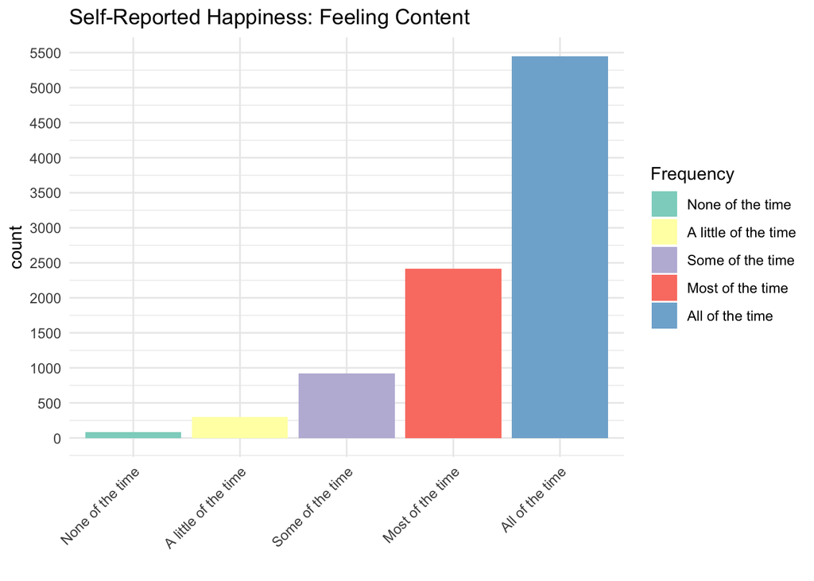

```r
#distribution of self-reported happiness
ggplot(savvydata, aes(savvydata$feeling_content, fill = savvydata$feeling_content))+
  geom_bar()+
  labs(title = "Self-Reported Happiness: Feeling Content", x = "", fill= "Frequency")+
  scale_x_discrete(guide = guide_axis(angle = 45 ))+
  scale_fill_brewer(palette = "Set3")+
  scale_y_continuous(breaks=c(0,500,1000,1500,2000,2500,3000,3500,
                              4000,4500,5000,5500))+
  theme_minimal()
```

Looking at ‘Self-Reported Happiness: Feeling Content’, we can see that out of 9171 observations, around almost 5500 observations have reported to ‘All of the time’ for feeling content (or None of the time for feeling depressed), which is much greater than those who reported ‘None of the time’ for feeling happy (84 observations). This can be a limitation of the study as it is imbalanced classes.

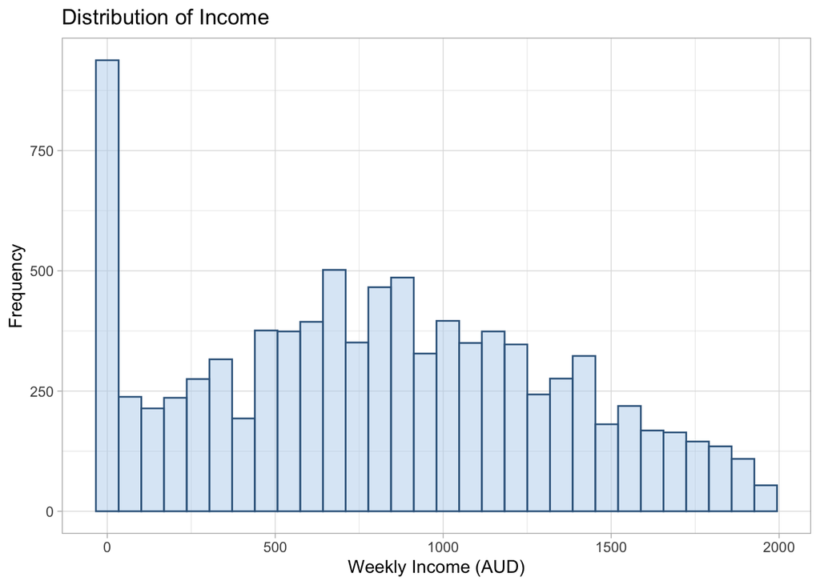

```r
#distribution of income
ggplot(savvydata, aes(x = income)) +
  geom_histogram(alpha = 0.5, position = "identity",
                 color = "steelblue4", fill = "slategray2")+
  labs(title = "Distribution of Income", x = "Weekly Income (AUD)", y = "Frequency")+
  theme_light()
```

```r
summary(savvydata$income)
```

```
##    Min. 1st Qu.  Median    Mean 3rd Qu.    Max.
##     1.0   407.0   779.0   810.3  1191.0  1961.0
```

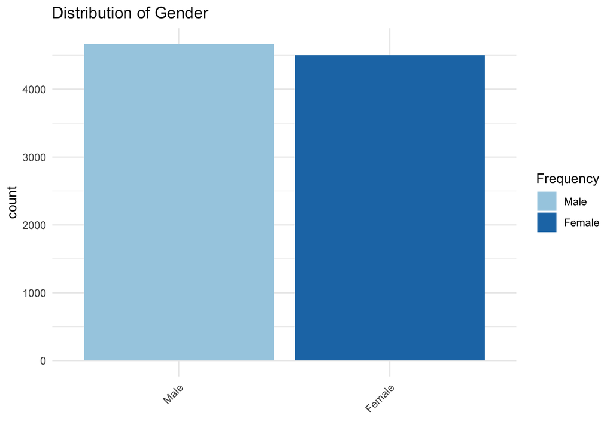

```r
#distribution of gender
ggplot(savvydata, aes(savvydata$gender, fill = savvydata$gender))+
  geom_bar()+
  labs(title = "Distribution of Gender", x = "", fill= "Frequency")+
  scale_x_discrete(guide = guide_axis(angle = 45 ))+
  scale_fill_brewer(palette = "Paired")+
  scale_y_continuous(breaks=c(0,1000,2000,3000,4000,5000))+
  theme_minimal()
```

The distribution of gender shows almost equal numbers for male and female respondents.

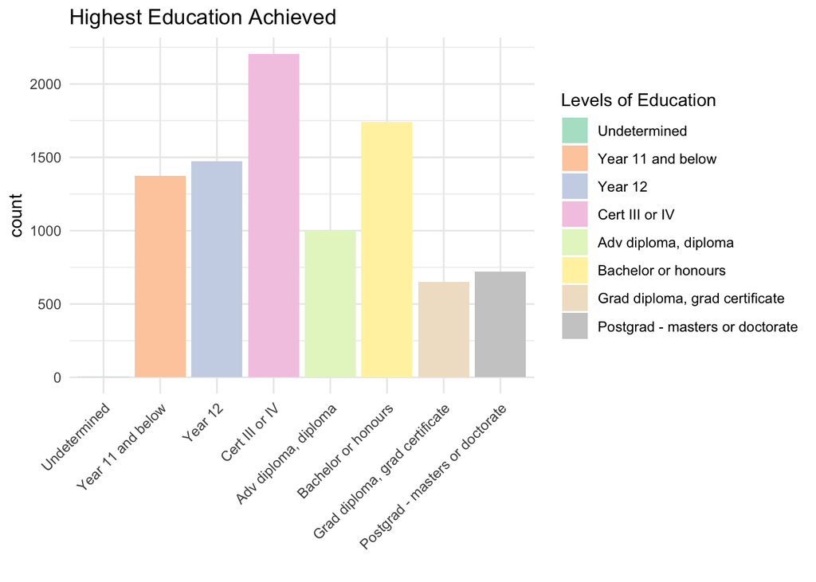

```r
#distribution of education levels
ggplot(savvydata, aes(savvydata$highest_education, fill = savvydata$highest_education))+
  geom_bar()+
  labs(title = "Highest Education Achieved", x = "", fill= "Levels of Education")+
  scale_x_discrete(guide = guide_axis(angle = 45 ))+
  scale_fill_brewer(palette = "Pastel2")+
  scale_y_continuous(breaks=c(0,500,1000,1500,2000,2500))+
  theme_minimal()
```

```r
summary(savvydata$highest_education)
```

```
##                    Undetermined               Year 11 and below
##                               3                            1375
##                         Year 12                  Cert III or IV
##                            1472                            2207
##            Adv diploma, diploma             Bachelor or honours
##                            1000                            1741
##  Grad diploma, grad certificate Postgrad - masters or doctorate
##                             652                             721
```

For highest education achieved, the barplot shows that most of the respondants reported having completed Cert III or IV (2207 observations or 24%), followed by Bachelor or honours degree (1741 observations or 19%), whereas Graduation diploma and graduate certificate qualifications account for the smallest number (652 observations or 7%).

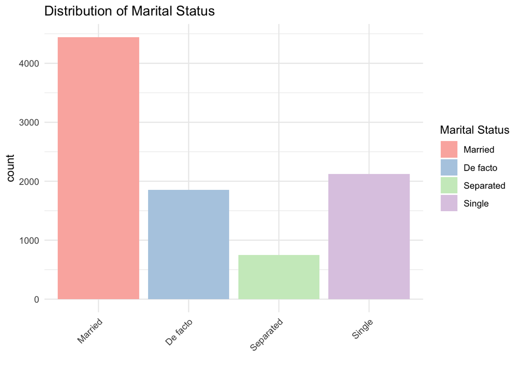

```r
#distribution of marital status
ggplot(savvydata, aes(savvydata$marital_status, fill = savvydata$marital_status))+
  geom_bar()+
  labs(title = "Distribution of Marital Status", x = "", fill= "Marital Status")+
  scale_x_discrete(guide = guide_axis(angle = 45 ))+
  scale_fill_brewer(palette = "Pastel1")+
  scale_y_continuous(breaks=c(0,1000,2000,3000,4000,5000))+
  theme_minimal()
```

```r
summary(savvydata$marital_status)
```

```
##   Married  De facto Separated    Single
##      4445      1855       747      2124
```

The distribution of marital status indicates that almost 50% of the respondents have reported that they are legally married. There are about 20% for respondents who are in a De Facto relationship, 8% for those who are separated and 23% for those who are single.

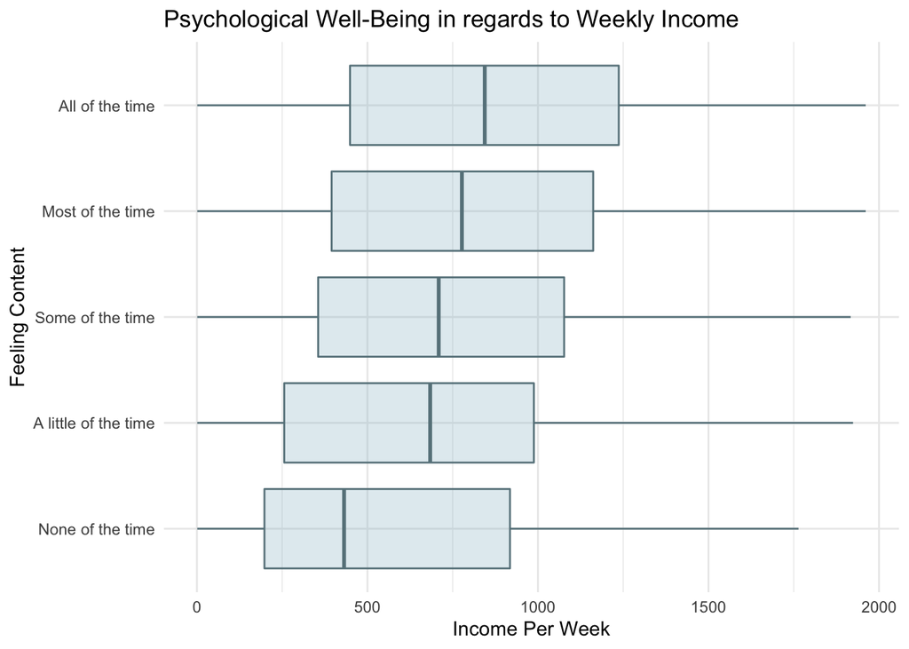

```r
#Psychological Well-Being in regards to Weekly Income
wellbeing_income <- ggplot(data=savvydata, aes(y=feeling_content, x = income))+
  geom_boxplot(alpha=0.3, fill = "lightblue3", color = "lightblue4")+
  labs(y="Feeling Content", x = "Income Per Week")+
  ggtitle("Psychological Well-Being in regards to Weekly Income")+
  theme_minimal()
plot(wellbeing_income)
```

From the visualisation above, there seems to be a relationship between weekly income and psychological well-being. In this case, the more weekly income is the rate of happiness also tends to increase.

```r
require(scales)
```

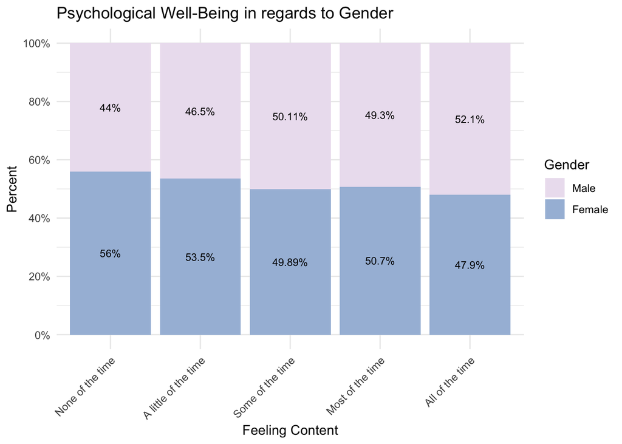

```r
#summary of Psychological Well-Being in regards to Gender
plotdata <- savvydata%>%
  group_by(feeling_content, gender) %>%
  summarise(n = n()) %>%
  mutate(pct = n/sum(n),
         lbl = scales::percent(pct))
#plot
ggplot(plotdata,
       aes(x = factor(feeling_content,
                      levels = c("None of the time","A little of the time","Some of the time",
                                 "Most of the time","All of the time")),
           y = pct,
           fill = factor(gender,
                         levels = c("Male","Female"))))+

  geom_bar(stat = "identity",
           position = "fill") +
  scale_x_discrete(guide = guide_axis(angle = 45 ))+
  scale_y_continuous(breaks = seq(0, 1, .2),
                     label = percent) +
  geom_text(aes(label = lbl),
            size = 3,
            position = position_stack(vjust = 0.5)) +
  scale_fill_brewer(palette = "PuBuGn") +
  labs(y = "Percent",
       fill = "Gender",
       x = "Feeling Content",
       title = "Psychological Well-Being in regards to Gender") +
  theme_minimal()
```

The plot of Psychological Well-Being in regards to Gender does not show a remarkable pattern but we can see that the percentage for ‘All of the time’ feeling content for male is slightly higher at 52.1% compared to female at 47.9%, whereas for ‘None of the time’ feeling content, the percentage of female is higher at 56% compared to male at 44%.

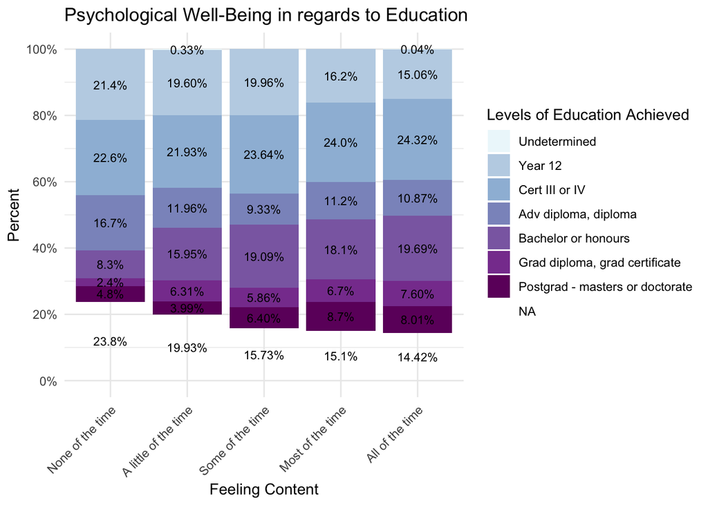

```r
#summary of Psychological Well-Being in regards to Levels of Education achieved
plotdata <- savvydata%>%
  group_by(feeling_content, highest_education) %>%
  summarise(n = n()) %>%
  mutate(pct = n/sum(n),
         lbl = scales::percent(pct))
#plot
ggplot(plotdata,
       aes(x = factor(feeling_content,
                      levels = c("None of the time","A little of the time","Some of the time",
                                 "Most of the time","All of the time")),
           y = pct,
           fill = factor(highest_education,
                         levels = c("Undetermined","Year 11 and below ","Year 12", "Cert III or IV",
                                    "Adv diploma, diploma", "Bachelor or honours","Grad diploma, grad certificate","Postgrad - masters or doctorate"))))+

  geom_bar(stat = "identity",
           position = "fill") +
  scale_x_discrete(guide = guide_axis(angle = 45 ))+
  scale_y_continuous(breaks = seq(0, 1, .2),
                     label = percent) +
  geom_text(aes(label = lbl),
            size = 3,
            position = position_stack(vjust = 0.5)) +
  scale_fill_brewer(palette = "BuPu") +
  labs(y = "Percent",
       fill = "Levels of Education Achieved",
       x = "Feeling Content",
       title = "Psychological Well-Being in regards to Education") +
  theme_minimal()
```

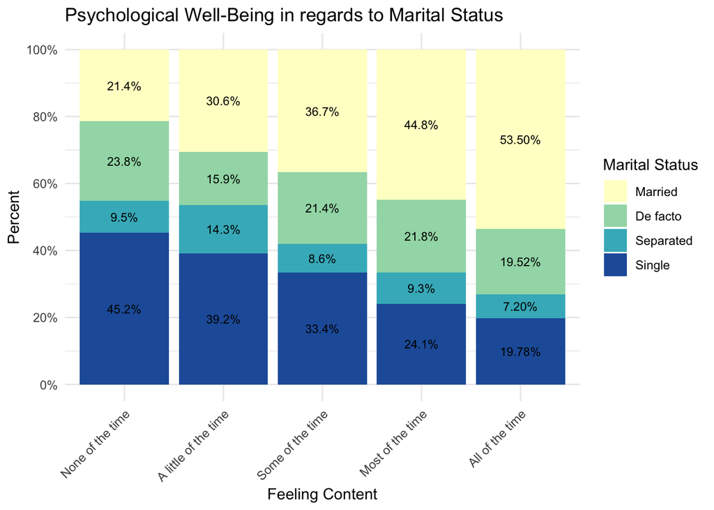

```r
#summary of Psychological Well-Being in regards to Marital Status
plotdata <- savvydata%>%
  group_by(feeling_content, marital_status) %>%
  summarise(n = n()) %>%
  mutate(pct = n/sum(n),
         lbl = scales::percent(pct))
#plot
ggplot(plotdata,
       aes(x = factor(feeling_content,
                      levels = c("None of the time","A little of the time","Some of the time",
                                 "Most of the time","All of the time")),
           y = pct,
           fill = factor(marital_status,
                         levels = c("Married","De facto","Separated", "Single"))))+

  geom_bar(stat = "identity",
           position = "fill") +
  scale_x_discrete(guide = guide_axis(angle = 45 ))+
  scale_y_continuous(breaks = seq(0, 1, .2),
                     label = percent) +
  geom_text(aes(label = lbl),
            size = 3,
            position = position_stack(vjust = 0.5)) +
  scale_fill_brewer(palette = "YlGnBu") +
  labs(y = "Percent",
       fill = "Marital Status",
       x = "Feeling Content",
       title = "Psychological Well-Being in regards to Marital Status") +
  theme_minimal()
```

The plot of Psychological Well-Being in regards to Marital Status shows that people who are married seem to be the happiest (53.50%) whereas those who are single have reported mostly for ‘None of the time’ feeling content (45.2%).

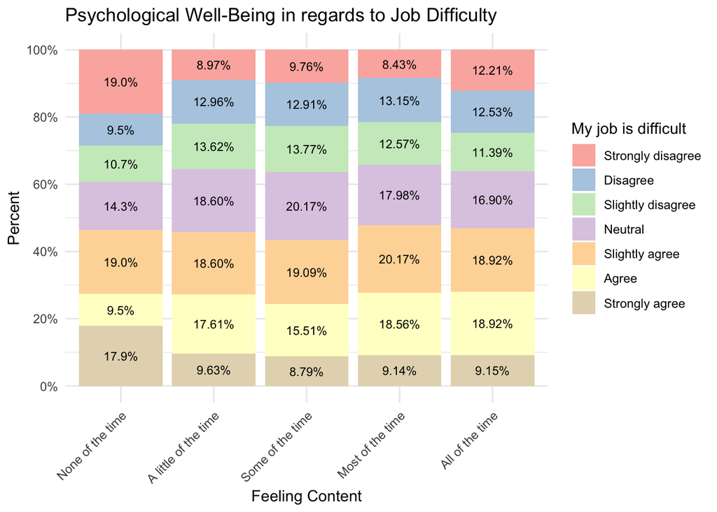

```r
#summary of Psychological Well-Being in regards to Job Difficulty
plotdata <- savvydata%>%
  group_by(feeling_content, job_difficult) %>%
  summarise(n = n()) %>%
  mutate(pct = n/sum(n),
         lbl = scales::percent(pct))
#plot
ggplot(plotdata,
       aes(x = factor(feeling_content,
                      levels = c("None of the time","A little of the time","Some of the time",
                                 "Most of the time","All of the time")),
           y = pct,
           fill = factor(job_difficult,
                         levels = c("Strongly disagree","Disagree","Slightly disagree","Neutral",
                                     "Slightly agree","Agree","Strongly agree"))))+

  geom_bar(stat = "identity",
           position = "fill") +
  scale_x_discrete(guide = guide_axis(angle = 45 ))+
  scale_y_continuous(breaks = seq(0, 1, .2),
                     label = percent) +
  geom_text(aes(label = lbl),
            size = 3,
            position = position_stack(vjust = 0.5)) +
  scale_fill_brewer(palette = "Pastel1") +
  labs(y = "Percent",
       fill = "My job is difficult",
       x = "Feeling Content",
       title = "Psychological Well-Being in regards to Job Difficulty") +
  theme_minimal()
```

The plot of psychological well-being in regards to job difficulty demonstrates relatively mixed patterns, that is respondents strongly agreeing that the job is difficult tend to report the most on ‘None of the time’ to feeling content (18%) and gradually decreasing as the scale changes from ‘A little of the time’ (10%), ‘Some of the time’ (8.79%), ‘Most of the time’ (9.14%) and ‘All of the time’ (9%). However, if we look at the scale ‘Strongly disagree’ to job difficulty, the percentage from ‘All of the time’ (12%) to ‘None of the time’ (19%) does not go exactly in descending order.

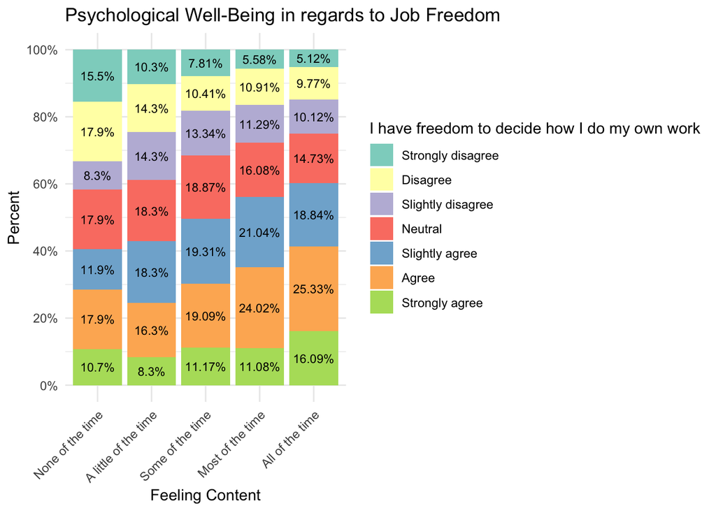

```r
#summary of Psychological Well-Being in regards to Job Freedom
plotdata <- savvydata%>%
  group_by(feeling_content, job_freedom) %>%
  summarise(n = n()) %>%
  mutate(pct = n/sum(n),
         lbl = scales::percent(pct))
#plot
ggplot(plotdata,
       aes(x = factor(feeling_content,
                      levels = c("None of the time","A little of the time","Some of the time",
                                 "Most of the time","All of the time")),
           y = pct,
           fill = factor(job_freedom,
                         levels = c("Strongly disagree","Disagree","Slightly disagree","Neutral",
                                     "Slightly agree","Agree","Strongly agree"))))+

  geom_bar(stat = "identity",
           position = "fill") +
  scale_x_discrete(guide = guide_axis(angle = 45 ))+
  scale_y_continuous(breaks = seq(0, 1, .2),
                     label = percent) +
  geom_text(aes(label = lbl),
            size = 3,
            position = position_stack(vjust = 0.5)) +
  scale_fill_brewer(palette = "Set3") +
  labs(y = "Percent",
       fill = "I have freedom to decide how I do my own work",
       x = "Feeling Content",
       title = "Psychological Well-Being in regards to Job Freedom") +
  theme_minimal()
```

The plot of psychological well-being in regards to job freedom illustrates that for respondents, who strongly disagreed that they have freedom to decide how they do their own work, reported most on ‘None of the time’ for feeling content (15%). The percentage gradually decreased as the opinion towards job freedom changes, that is respondents who strongly disagreed that they have freedom tend to report the least for ‘All of the time’ for feeling content (5.12%).

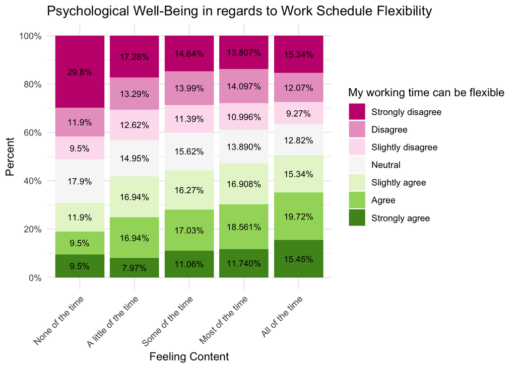

```r
#summary of Psychological Well-Being in regards to Work Schedule Flexibility
plotdata <- savvydata%>%
  group_by(feeling_content, job_flexibletime) %>%
  summarise(n = n()) %>%
  mutate(pct = n/sum(n),
         lbl = scales::percent(pct))
#plot
ggplot(plotdata,
       aes(x = factor(feeling_content,
                      levels = c("None of the time","A little of the time","Some of the time",
                                 "Most of the time","All of the time")),
           y = pct,
           fill = factor(job_flexibletime,
                         levels = c("Strongly disagree","Disagree","Slightly disagree","Neutral",
                                     "Slightly agree","Agree","Strongly agree"))))+

  geom_bar(stat = "identity",
           position = "fill") +
  scale_x_discrete(guide = guide_axis(angle = 45 ))+
  scale_y_continuous(breaks = seq(0, 1, .2),
                     label = percent) +
  geom_text(aes(label = lbl),
            size = 3,
            position = position_stack(vjust = 0.5)) +
  scale_fill_brewer(palette = "PiYG") +
  labs(y = "Percent",
       fill = "My working time can be flexible",
       x = "Feeling Content",
       title = "Psychological Well-Being in regards to Work Schedule Flexibility") +
  theme_minimal()
```

The plot of psychological well-being in regards to work schedule flexibility demonstrates quite a mixed pattern also, that is, respondents who strongly disagreed that their work schedule is flexible seems to be the least happy as 30% of them reported ‘None of the time’ to feeling content, followed by 17%, 14.64% and 13.81% who reported ‘A little of the time’, ‘Some of the time’ and ‘Most of the time’ to feeling content, respectively. However, the percentage increases at the scale ‘All of the time’ at 15%

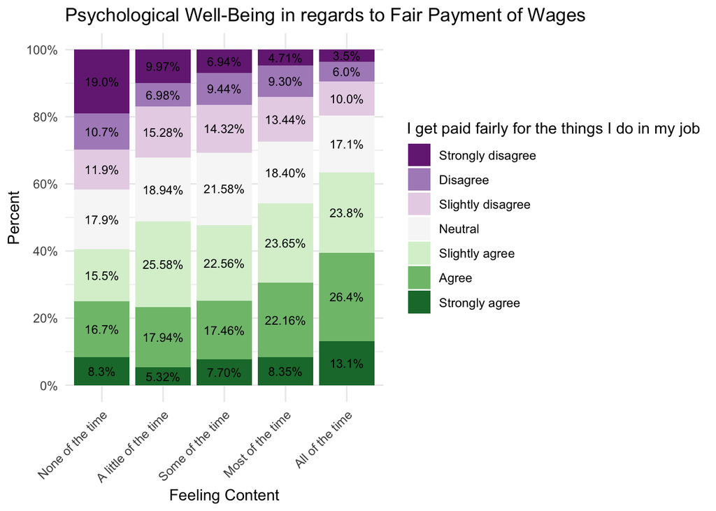

```r
#summary of Psychological Well-Being in regards to Fair Payment of Wages
plotdata <- savvydata%>%
  group_by(feeling_content, job_fairpayment) %>%
  summarise(n = n()) %>%
  mutate(pct = n/sum(n),
         lbl = scales::percent(pct))
#plot
ggplot(plotdata,
       aes(x = factor(feeling_content,
                      levels = c("None of the time","A little of the time","Some of the time",
                                 "Most of the time","All of the time")),
           y = pct,
           fill = factor(job_fairpayment,
                         levels = c("Strongly disagree","Disagree","Slightly disagree","Neutral",
                                     "Slightly agree","Agree","Strongly agree"))))+

  geom_bar(stat = "identity",
           position = "fill") +
  scale_x_discrete(guide = guide_axis(angle = 45 ))+
  scale_y_continuous(breaks = seq(0, 1, .2),
                     label = percent) +
  geom_text(aes(label = lbl),
            size = 3,
            position = position_stack(vjust = 0.5)) +
  scale_fill_brewer(palette = "PRGn") +
  labs(y = "Percent",
       fill = "I get paid fairly for the things I do in my job",
       x = "Feeling Content",
       title = "Psychological Well-Being in regards to Fair Payment of Wages") +
  theme_minimal()
```

The plot of psychological well-being in regards to fair payment of wages shows that there seems to be a positive relationship between fair payment of wages and feeling content. In this case, if we look at the ‘All of the time’ feeling content scale, we can see that there seems to be more percentage of respondents who strongly agreed (13.1%), agreed (26.4%) and slightly agree (23.8%) than those who disagreed. Furthermore, if we look at ‘Strongly disagree’ scale for all ‘Feeling Content’ scale values we can see that there is an obvious descent of percentage from ‘None of the time’ (19%) to ‘All of the time’ (3.5%).

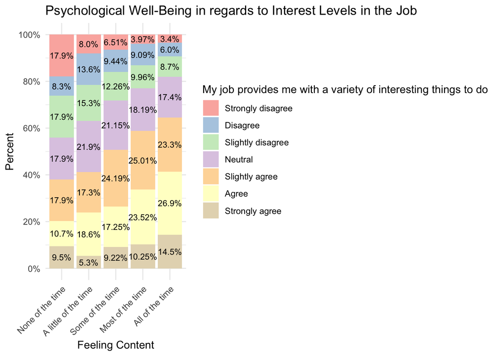

```r
#summary of Psychological Well-Being in regards to Interest Levels in the Job
plotdata <- savvydata%>%
  group_by(feeling_content, job_interesting) %>%
  summarise(n = n()) %>%
  mutate(pct = n/sum(n),
         lbl = scales::percent(pct))
#plot
ggplot(plotdata,
       aes(x = factor(feeling_content,
                      levels = c("None of the time","A little of the time","Some of the time",
                                 "Most of the time","All of the time")),
           y = pct,
           fill = factor(job_interesting,
                         levels = c("Strongly disagree","Disagree","Slightly disagree","Neutral",
                                     "Slightly agree","Agree","Strongly agree"))))+

  geom_bar(stat = "identity",
           position = "fill") +
  scale_x_discrete(guide = guide_axis(angle = 45 ))+
  scale_y_continuous(breaks = seq(0, 1, .2),
                     label = percent) +
  geom_text(aes(label = lbl),
            size = 3,
            position = position_stack(vjust = 0.5)) +
  scale_fill_brewer(palette = "Pastel1") +
  labs(y = "Percent",
       fill = "My job provides me with a variety of interesting things to do",
       x = "Feeling Content",
       title = "Psychological Well-Being in regards to Interest Levels in the Job") +
  theme_minimal()
```

The plot of psychological well-being in regards to interest levels in the job shows that respondents who strongly disagreed that their job is interesting reported the most on ‘None of the time’ for feeling content (18%) and the least on ‘All of the time’ for feeling content.

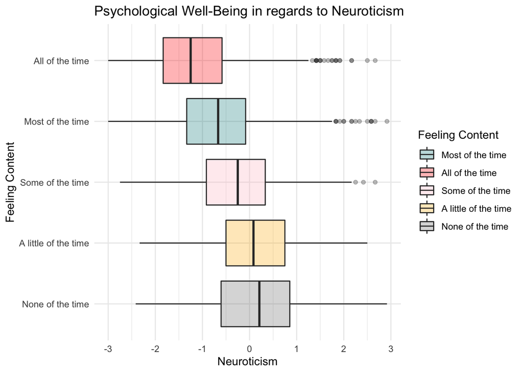

```r
#Psychological Well-Being in regards to Neuroticism
wellbeing_emotional <- ggplot(data=savvydata, aes(y=feeling_content, x = Neuroticism, fill = savvydata$feeling_content))+
  geom_boxplot(alpha=0.3)+
  scale_fill_manual(breaks = savvydata$feeling_content,
                    values = c("cyan4","red","pink", "mediumpurple", "darkgoldenrod1"))+
  labs(y="Feeling Content", x = "Neuroticism", fill = "Feeling Content")+
  ggtitle("Psychological Well-Being in regards to Neuroticism")+
  scale_x_continuous(breaks=c(-4,-3,-2,-1,0,1,2,3,4))+
  theme_minimal()
plot(wellbeing_emotional)
```

The boxplot of Psychological Well-Being in regards to Neuroticism shows that those who reported ‘None of the time’ feeling content tend to score higher for Neuroticism, whereas those who reported ‘All of the time’ feeling content evidently scored low for Neuroticism (with the average being lower than -1 on the scale). In other words, those who scored high in neuroticism tend to be less happy and those who scored less in neuroticism are happier.

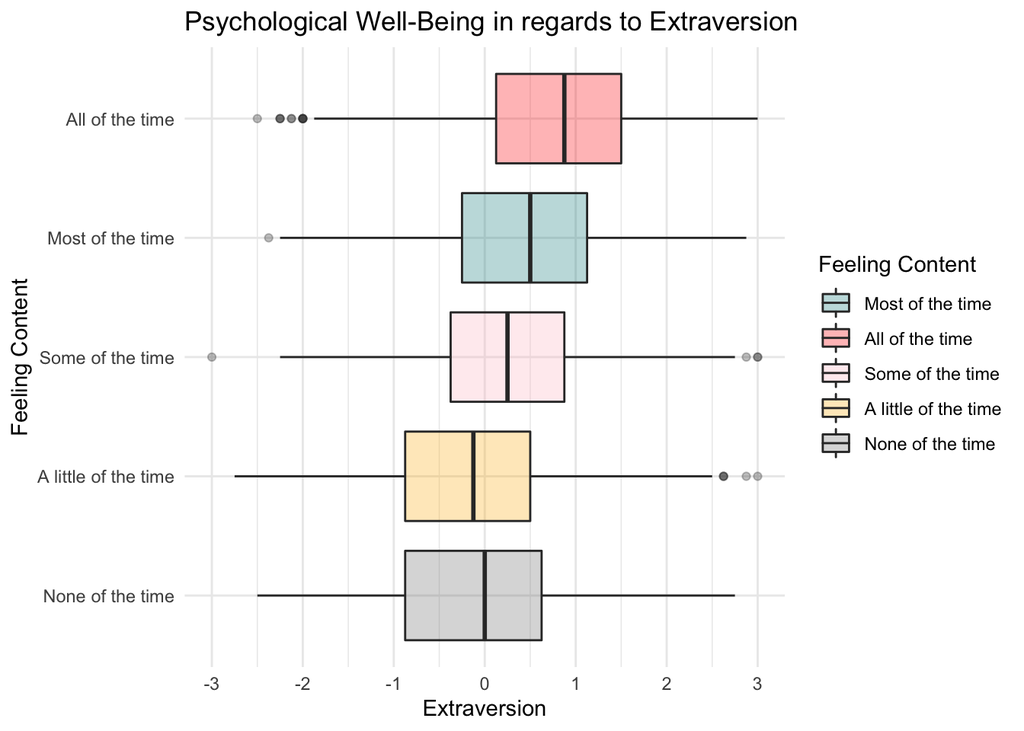

```r
#Psychological Well-Being in regards to Extraversion
wellbeing_extraversion <- ggplot(data=savvydata, aes(y=feeling_content, x = Extraversion, fill = savvydata$feeling_content))+
  geom_boxplot(alpha=0.3)+
  scale_fill_manual(breaks = savvydata$feeling_content,
                    values = c("cyan4","red","pink", "mediumpurple", "darkgoldenrod1"))+
  labs(y="Feeling Content", x = "Extraversion", fill = "Feeling Content")+
  ggtitle("Psychological Well-Being in regards to Extraversion")+
  scale_x_continuous(breaks=c(-5,-4,-3,-2, -1,0,1,2,3,4,5,6,7))+
  theme_minimal()
plot(wellbeing_extraversion)
```

The boxplot of Psychological Well-Being in regards to Extraversion shows that those who have reported ‘All of the time’ feeling content seem to be extrovert. The level of extraversion also gradually decreases as the frequency of happiness decreases, except for ‘None of the time’ feeling content that shows a slightly higher level of Extraversion than ‘A little of the time’.

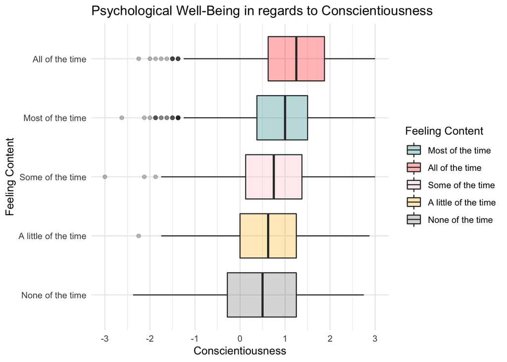

```r
#Psychological Well-Being in regards to Conscientiousness
wellbeing_con <- ggplot(data=savvydata, aes(y=feeling_content, x = Conscientiousness, fill = savvydata$feeling_content))+
  geom_boxplot(alpha=0.3)+
  scale_fill_manual(breaks = savvydata$feeling_content,
                    values = c("cyan4","red","pink", "mediumpurple", "darkgoldenrod1"))+
  labs(y="Feeling Content", x = "Conscientiousness", fill = "Feeling Content")+
  ggtitle("Psychological Well-Being in regards to Conscientiousness")+
  scale_x_continuous(breaks=c(-4,-3,-2,-1,0,1,2,3,4,5,6,7))+
  theme_minimal()
plot(wellbeing_con)
```

The boxplot of Psychological Well-Being in regards to Conscientiousness shows that respondents who scored higher in Conscientiousness are happier.

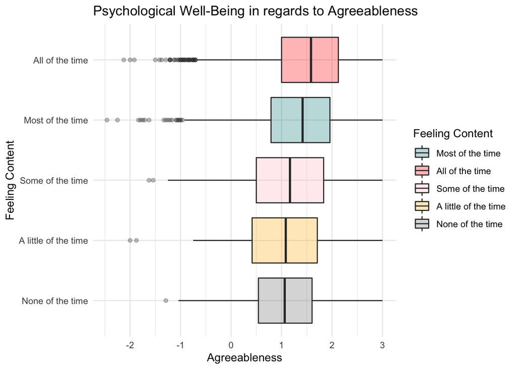

```r
#Psychological Well-Being in regards to Agreeableness
wellbeing_agree <- ggplot(data=savvydata, aes(y=feeling_content, x = Agreeableness, fill = savvydata$feeling_content))+
  geom_boxplot(alpha=0.3)+
  scale_fill_manual(breaks = savvydata$feeling_content,
                    values = c("cyan4","red","pink", "mediumpurple", "darkgoldenrod1"))+
  labs(y="Feeling Content", x = "Agreeableness", fill = "Feeling Content")+
  ggtitle("Psychological Well-Being in regards to Agreeableness")+
  scale_x_continuous(breaks=c(-4,-3,-2,-1,0,1,2,3))+
  theme_minimal()
plot(wellbeing_agree)
```

The boxplot of Psychological Well-Being in regards to Agreeableness shows that respondents who scored higher in Agreeableness are happier.

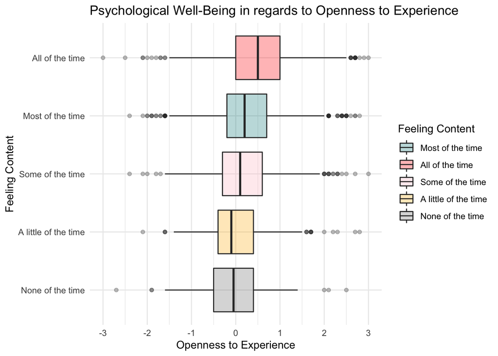

```r
#Psychological Well-Being in regards to Openness to Experience
wellbeing_open <- ggplot(data=savvydata, aes(y=feeling_content, x = OpennessToExperience, fill = savvydata$feeling_content))+
  geom_boxplot(alpha=0.3)+
  scale_fill_manual(breaks = savvydata$feeling_content,
                    values = c("cyan4","red","pink", "mediumpurple", "darkgoldenrod1"))+
  labs(y="Feeling Content", x = "Openness to Experience", fill = "Feeling Content")+
  ggtitle("Psychological Well-Being in regards to Openness to Experience")+
  scale_x_continuous(breaks=c(-4,-3,-2,-1,0,1,2,3,4))+
  theme_minimal()
plot(wellbeing_open)
```

The boxplot of Psychological Well-Being in regards to Openness to Experience shows that respondents who scored higher in Openness to Experience are happier.

The hypothese to analyze the factors contributing to psychological well-being and the relationship between input variables and target variable are as follows:

Null Hypothesis H0 : There is no association between any input variables and target variable, meaning that there is no relationship between psychological well-being and observed factors. H1 : Personality traits have a stronger influence on psychological well-being than external factors H2 : Higher income increases happiness H3 : Married people are happier than people of other marital status H4 : The personality trait neuroticism is negatively associated with psychological well-being. H5 : The personality trait extraversion is positively associated with psychological well-being. H6 : The personality trait conscientiousness is positively associated with psychological well-being. H7 : The personality trait agreeableness is positively associated with psychological well-being. H8 : The personality trait openness to experience is positively associated with psychological well-being.

## Model Construction

Next the models will be fit. Train and test data will be splited into 70% for training and 30% for testing for models evaluation.

```r
library(caret)
intrain <- createDataPartition(y = savvydata$feeling_content, p =0.7, list = FALSE)
training <- savvydata[intrain,]
testing <- savvydata[-intrain,]

dim(training)
```

```
## [1] 6422   51
```

```r
dim(testing)
```

```
## [1] 2749   51
```

There will be a total of three models including one with only external factors, one with only Big Five Personality factors and the other one is the combination of both external factors and personality traits. The first two models will be compared to test the hypothesis ‘H01 : Personality traits have a stronger influence on psychological well-being than external factors’. The best model of all three will be selected to interpret how the observed factors influence psychological well-being.

#### Model 1

The first model will be external factor variables (with out personality traits) to measure how well it predicts the psychological well-being or happiness.

```r
# Model 1 - External Factors
fit_external <- vglm(feeling_content ~ income + highest_education + gender + marital_status + job_difficult + job_freedom + job_flexibletime + job_fairpayment + job_interesting, cumulative(parallel=TRUE),data=training)

summary(fit_external)
```

```
##
## Call:
## vglm(formula = feeling_content ~ income + highest_education +
##     gender + marital_status + job_difficult + job_freedom + job_flexibletime +
##     job_fairpayment + job_interesting, family = cumulative(parallel = TRUE),
##     data = training)
##
## Coefficients:
##                                                    Estimate Std. Error z value
## (Intercept):1                                    -4.695e+00  1.120e+00  -4.193
## (Intercept):2                                    -3.124e+00  1.114e+00  -2.805
## (Intercept):3                                    -1.758e+00  1.113e+00  -1.580
## (Intercept):4                                    -2.743e-01  1.112e+00  -0.247
## income                                           -2.626e-04  5.539e-05  -4.741
## highest_educationYear 11 and below                4.480e-01  1.113e+00   0.403
## highest_educationYear 12                          4.556e-01  1.113e+00   0.409
## highest_educationCert III or IV                   4.373e-01  1.112e+00   0.393
## highest_educationAdv diploma, diploma             5.136e-01  1.114e+00   0.461
## highest_educationBachelor or honours              4.591e-01  1.113e+00   0.412
## highest_educationGrad diploma, grad certificate   4.987e-01  1.117e+00   0.447
## highest_educationPostgrad - masters or doctorate  5.208e-01  1.116e+00   0.467
## genderFemale                                      9.674e-02  5.048e-02   1.917
## marital_statusDe facto                            2.342e-01  6.688e-02   3.502
## marital_statusSeparated                           5.140e-01  9.322e-02   5.514
## marital_statusSingle                              5.703e-01  6.655e-02   8.570
## job_difficultDisagree                             3.388e-01  1.119e-01   3.027
## job_difficultSlightly disagree                    4.691e-01  1.143e-01   4.105
## job_difficultNeutral                              5.459e-01  1.076e-01   5.076
## job_difficultSlightly agree                       5.953e-01  1.082e-01   5.501
## job_difficultAgree                                6.678e-01  1.121e-01   5.956
## job_difficultStrongly agree                       8.612e-01  1.272e-01   6.773
## job_freedomDisagree                              -1.341e-01  1.311e-01  -1.023
## job_freedomSlightly disagree                     -8.878e-02  1.320e-01  -0.673
## job_freedomNeutral                               -4.677e-02  1.267e-01  -0.369
## job_freedomSlightly agree                        -9.970e-03  1.261e-01  -0.079
## job_freedomAgree                                 -1.436e-01  1.267e-01  -1.134
## job_freedomStrongly agree                        -2.101e-01  1.417e-01  -1.482
## job_flexibletimeDisagree                          1.593e-01  9.864e-02   1.615
## job_flexibletimeSlightly disagree                 1.254e-01  1.052e-01   1.192
## job_flexibletimeNeutral                           1.729e-01  9.849e-02   1.755
```

[output cut: 147 more lines]

```
##                                        0.4768080
##                    job_fairpaymentStrongly agree
##                                        0.3966680
##                          job_interestingDisagree
##                                        0.8440905
##                 job_interestingSlightly disagree
##                                        0.6836502
##                           job_interestingNeutral
##                                        0.5695738
##                    job_interestingSlightly agree
##                                        0.5124443
##                             job_interestingAgree
##                                        0.4376341
##                    job_interestingStrongly agree
##                                        0.3710063
```

Stepwise regression uses statistical significance to select variables to be used in regression models.

```r
#stepwise regression
stepwise <- step4(fit_external)
```

```
## Start:  AIC=13114.88
## feeling_content ~ income + highest_education + gender + marital_status +
##     job_difficult + job_freedom + job_flexibletime + job_fairpayment +
##     job_interesting
##
##                     Df Deviance   AIC
## - highest_education  7    13024 13102
## - job_flexibletime   6    13028 13108
## - job_freedom        6    13029 13109
## <none>                    13023 13115
## - gender             1    13026 13116
## - income             1    13046 13136
## - job_difficult      6    13078 13158
## - job_interesting    6    13095 13175
## - job_fairpayment    6    13102 13182
## - marital_status     3    13108 13194
##
## Step:  AIC=13102.23
## feeling_content ~ income + gender + marital_status + job_difficult +
##     job_freedom + job_flexibletime + job_fairpayment + job_interesting
##
##                    Df Deviance   AIC
## - job_flexibletime  6    13030 13096
## - job_freedom       6    13030 13096
## <none>                   13024 13102
## - gender            1    13028 13104
## - income            1    13046 13122
## - job_difficult     6    13083 13149
## - job_interesting   6    13096 13162
## - job_fairpayment   6    13104 13170
## - marital_status    3    13111 13183
##
## Step:  AIC=13095.78
## feeling_content ~ income + gender + marital_status + job_difficult +
##     job_freedom + job_fairpayment + job_interesting
##
##                   Df Deviance   AIC
## - job_freedom      6    13038 13092
## <none>                  13030 13096
## - gender           1    13034 13098
## - income           1    13052 13116
## - job_difficult    6    13089 13143
## - job_interesting  6    13104 13158
## - job_fairpayment  6    13111 13165
## - marital_status   3    13119 13179
##
## Step:  AIC=13092.07
## feeling_content ~ income + gender + marital_status + job_difficult +
##     job_fairpayment + job_interesting
##
##                   Df Deviance   AIC
## <none>                  13038 13092
## - gender           1    13042 13094
## - income           1    13059 13111
## - job_difficult    6    13099 13141
## - job_fairpayment  6    13126 13168
## - job_interesting  6    13130 13172
## - marital_status   3    13132 13180
```

```r
summary(stepwise)
```

```
##
## Call:
## vglm(formula = feeling_content ~ income + gender + marital_status +
##     job_difficult + job_fairpayment + job_interesting, family = cumulative(parallel = TRUE),
##     data = training)
##
## Coefficients:
##                                    Estimate Std. Error z value Pr(>|z|)
## (Intercept):1                    -4.271e+00  2.047e-01 -20.868  < 2e-16 ***
## (Intercept):2                    -2.700e+00  1.696e-01 -15.925  < 2e-16 ***
## (Intercept):3                    -1.334e+00  1.624e-01  -8.214  < 2e-16 ***
## (Intercept):4                     1.464e-01  1.615e-01   0.907 0.364669
## income                           -2.401e-04  5.304e-05  -4.527 5.98e-06 ***
## genderFemale                      9.884e-02  5.036e-02   1.963 0.049683 *
## marital_statusDe facto            2.441e-01  6.640e-02   3.676 0.000237 ***
## marital_statusSeparated           5.130e-01  9.275e-02   5.531 3.18e-08 ***
## marital_statusSingle              5.897e-01  6.450e-02   9.144  < 2e-16 ***
## job_difficultDisagree             3.561e-01  1.108e-01   3.215 0.001304 **
## job_difficultSlightly disagree    4.846e-01  1.130e-01   4.288 1.80e-05 ***
## job_difficultNeutral              5.715e-01  1.063e-01   5.374 7.70e-08 ***
## job_difficultSlightly agree       6.235e-01  1.068e-01   5.836 5.35e-09 ***
## job_difficultAgree                6.925e-01  1.105e-01   6.268 3.66e-10 ***
## job_difficultStrongly agree       8.735e-01  1.252e-01   6.974 3.08e-12 ***
## job_fairpaymentDisagree          -2.438e-01  1.422e-01  -1.714 0.086501 .
## job_fairpaymentSlightly disagree -2.379e-01  1.334e-01  -1.784 0.074423 .
## job_fairpaymentNeutral           -4.385e-01  1.274e-01  -3.441 0.000580 ***
## job_fairpaymentSlightly agree    -5.282e-01  1.256e-01  -4.204 2.62e-05 ***
## job_fairpaymentAgree             -7.406e-01  1.264e-01  -5.860 4.63e-09 ***
## job_fairpaymentStrongly agree    -9.534e-01  1.416e-01  -6.733 1.66e-11 ***
## job_interestingDisagree          -1.542e-01  1.467e-01  -1.051 0.293183
## job_interestingSlightly disagree -3.538e-01  1.419e-01  -2.492 0.012689 *
## job_interestingNeutral           -5.363e-01  1.337e-01  -4.012 6.01e-05 ***
## job_interestingSlightly agree    -6.375e-01  1.326e-01  -4.806 1.54e-06 ***
## job_interestingAgree             -8.258e-01  1.343e-01  -6.147 7.89e-10 ***
## job_interestingStrongly agree    -1.042e+00  1.460e-01  -7.140 9.31e-13 ***
## ---
## Signif. codes:  0 '***' 0.001 '**' 0.01 '*' 0.05 '.' 0.1 ' ' 1
##
## Names of linear predictors: logitlink(P[Y<=1]), logitlink(P[Y<=2]),
## logitlink(P[Y<=3]), logitlink(P[Y<=4])
```

[output cut: 20 more lines]

```
##                        1.8654744                        1.9987513
##      job_difficultStrongly agree          job_fairpaymentDisagree
##                        2.3953049                        0.7836483
## job_fairpaymentSlightly disagree           job_fairpaymentNeutral
##                        0.7882718                        0.6449830
##    job_fairpaymentSlightly agree             job_fairpaymentAgree
##                        0.5896854                        0.4768319
##    job_fairpaymentStrongly agree          job_interestingDisagree
##                        0.3854314                        0.8570834
## job_interestingSlightly disagree           job_interestingNeutral
##                        0.7020425                        0.5849084
##    job_interestingSlightly agree             job_interestingAgree
##                        0.5286150                        0.4378872
##    job_interestingStrongly agree
##                        0.3525754
```

Next the ordinal logistic regression will be fit to build the proportional odds logistic regression to predict the class of multi-class ordered variables.

```r
#Polr
fitpolr_external <- polr(feeling_content ~ income + marital_status + job_difficult +
    job_fairpayment + job_interesting, data = training, Hess = TRUE)
summary(fitpolr_external)
```

```
## Call:
## polr(formula = feeling_content ~ income + marital_status + job_difficult +
##     job_fairpayment + job_interesting, data = training, Hess = TRUE)
##
## Coefficients:
##                                       Value Std. Error t value
## income                            0.0002429  0.0000548   4.433
## marital_statusDe facto           -0.2484342  0.0657914  -3.776
## marital_statusSeparated          -0.5256747  0.0919572  -5.717
## marital_statusSingle             -0.5947088  0.0645735  -9.210
## job_difficultDisagree            -0.3519814  0.0700043  -5.028
## job_difficultSlightly disagree   -0.4779219  0.0691946  -6.907
## job_difficultNeutral             -0.5649379  0.0592432  -9.536
## job_difficultSlightly agree      -0.6208535  0.0568782 -10.915
## job_difficultAgree               -0.6895931  0.0608349 -11.335
## job_difficultStrongly agree      -0.8678246  0.0797967 -10.875
## job_fairpaymentDisagree           0.2426517  0.0776660   3.124
## job_fairpaymentSlightly disagree  0.2383552  0.0649834   3.668
## job_fairpaymentNeutral            0.4391675  0.0569325   7.714
## job_fairpaymentSlightly agree     0.5288158  0.0533511   9.912
## job_fairpaymentAgree              0.7440532  0.0546374  13.618
## job_fairpaymentStrongly agree     0.9518275  0.0786338  12.105
## job_interestingDisagree           0.1459432  0.0822850   1.774
## job_interestingSlightly disagree  0.3492213  0.0735580   4.748
## job_interestingNeutral            0.5300886  0.0587655   9.020
## job_interestingSlightly agree     0.6313916  0.0531779  11.873
## job_interestingAgree              0.8171578  0.0553086  14.775
## job_interestingStrongly agree     1.0330122  0.0751717  13.742
##
## Intercepts:
##                                       Value    Std. Error t value
## None of the time|A little of the time  -4.2236   0.0860   -49.1261
## A little of the time|Some of the time  -2.6532   0.0699   -37.9713
## Some of the time|Most of the time      -1.2875   0.0635   -20.2763
## Most of the time|All of the time        0.1925   0.0619     3.1106
##
## Residual Deviance: 13041.92
## AIC: 13093.92
```

We will again check p-value to see if there are any non-significant variables that do not need interpretation.

```r
# p-Value Calculation
(ctable <- coef(summary(fitpolr_external)))
```

```
##                                               Value   Std. Error    t value
## income                                 0.0002429164 5.479505e-05   4.433181
## marital_statusDe facto                -0.2484341723 6.579140e-02  -3.776089
## marital_statusSeparated               -0.5256747476 9.195721e-02  -5.716515
## marital_statusSingle                  -0.5947087730 6.457350e-02  -9.209796
## job_difficultDisagree                 -0.3519814132 7.000426e-02  -5.028000
## job_difficultSlightly disagree        -0.4779219443 6.919463e-02  -6.906923
## job_difficultNeutral                  -0.5649378901 5.924324e-02  -9.535904
## job_difficultSlightly agree           -0.6208535073 5.687823e-02 -10.915486
## job_difficultAgree                    -0.6895931114 6.083492e-02 -11.335481
## job_difficultStrongly agree           -0.8678246135 7.979672e-02 -10.875443
## job_fairpaymentDisagree                0.2426516680 7.766598e-02   3.124298
## job_fairpaymentSlightly disagree       0.2383551776 6.498342e-02   3.667938
## job_fairpaymentNeutral                 0.4391674774 5.693246e-02   7.713832
## job_fairpaymentSlightly agree          0.5288158056 5.335113e-02   9.911990
## job_fairpaymentAgree                   0.7440532443 5.463737e-02  13.618029
## job_fairpaymentStrongly agree          0.9518275266 7.863377e-02  12.104564
## job_interestingDisagree                0.1459432203 8.228497e-02   1.773632
## job_interestingSlightly disagree       0.3492213127 7.355802e-02   4.747563
## job_interestingNeutral                 0.5300885513 5.876548e-02   9.020407
## job_interestingSlightly agree          0.6313915647 5.317793e-02  11.873188
## job_interestingAgree                   0.8171577703 5.530856e-02  14.774527
## job_interestingStrongly agree          1.0330122483 7.517166e-02  13.742043
## None of the time|A little of the time -4.2236140854 8.597500e-02 -49.126072
## A little of the time|Some of the time -2.6532039203 6.987387e-02 -37.971333
## Some of the time|Most of the time     -1.2875201045 6.349891e-02 -20.276255
## Most of the time|All of the time       0.1925068735 6.188676e-02   3.110631
```

```r
p <- pnorm(abs(ctable[, "t value"]), lower.tail = FALSE) * 2
(ctable <- cbind(ctable, "p value" = p))
```

```
##                                               Value   Std. Error    t value
## income                                 0.0002429164 5.479505e-05   4.433181
## marital_statusDe facto                -0.2484341723 6.579140e-02  -3.776089
## marital_statusSeparated               -0.5256747476 9.195721e-02  -5.716515
## marital_statusSingle                  -0.5947087730 6.457350e-02  -9.209796
## job_difficultDisagree                 -0.3519814132 7.000426e-02  -5.028000
## job_difficultSlightly disagree        -0.4779219443 6.919463e-02  -6.906923
## job_difficultNeutral                  -0.5649378901 5.924324e-02  -9.535904
## job_difficultSlightly agree           -0.6208535073 5.687823e-02 -10.915486
## job_difficultAgree                    -0.6895931114 6.083492e-02 -11.335481
## job_difficultStrongly agree           -0.8678246135 7.979672e-02 -10.875443
## job_fairpaymentDisagree                0.2426516680 7.766598e-02   3.124298
## job_fairpaymentSlightly disagree       0.2383551776 6.498342e-02   3.667938
## job_fairpaymentNeutral                 0.4391674774 5.693246e-02   7.713832
## job_fairpaymentSlightly agree          0.5288158056 5.335113e-02   9.911990
## job_fairpaymentAgree                   0.7440532443 5.463737e-02  13.618029
## job_fairpaymentStrongly agree          0.9518275266 7.863377e-02  12.104564
## job_interestingDisagree                0.1459432203 8.228497e-02   1.773632
## job_interestingSlightly disagree       0.3492213127 7.355802e-02   4.747563
## job_interestingNeutral                 0.5300885513 5.876548e-02   9.020407
## job_interestingSlightly agree          0.6313915647 5.317793e-02  11.873188
## job_interestingAgree                   0.8171577703 5.530856e-02  14.774527
## job_interestingStrongly agree          1.0330122483 7.517166e-02  13.742043
## None of the time|A little of the time -4.2236140854 8.597500e-02 -49.126072
## A little of the time|Some of the time -2.6532039203 6.987387e-02 -37.971333
## Some of the time|Most of the time     -1.2875201045 6.349891e-02 -20.276255
## Most of the time|All of the time       0.1925068735 6.188676e-02   3.110631
##                                            p value
## income                                9.285289e-06
## marital_statusDe facto                1.593101e-04
## marital_statusSeparated               1.087312e-08
## marital_statusSingle                  3.267466e-20
## job_difficultDisagree                 4.956230e-07
## job_difficultSlightly disagree        4.952802e-12
## job_difficultNeutral                  1.485846e-21
## job_difficultSlightly agree           9.720792e-28
## job_difficultAgree                    8.754956e-30
## job_difficultStrongly agree           1.509215e-27
## job_fairpaymentDisagree               1.782297e-03
## job_fairpaymentSlightly disagree      2.445144e-04
## job_fairpaymentNeutral                1.220950e-14
## job_fairpaymentSlightly agree         3.692187e-23
## job_fairpaymentAgree                  3.128984e-42
## job_fairpaymentStrongly agree         9.989919e-34
## job_interestingDisagree               7.612410e-02
## job_interestingSlightly disagree      2.058824e-06
## job_interestingNeutral                1.873920e-19
## job_interestingSlightly agree         1.631302e-32
## job_interestingAgree                  2.138533e-49
## job_interestingStrongly agree         5.684830e-43
## None of the time|A little of the time 0.000000e+00
## A little of the time|Some of the time 0.000000e+00
## Some of the time|Most of the time     2.084058e-91
## Most of the time|All of the time      1.866882e-03
```

The coefficients from the model can be difficult to interpret because they are scaled in terms of logs. To interpret logistic regression models, we can convert the coefficients into odds ratios.

```r
ci <- confint.default(fitpolr_external)
exp(cbind(OR = coef(fitpolr_external), ci))
```

```
##                                         OR     2.5 %    97.5 %
## income                           1.0002429 1.0001355 1.0003504
## marital_statusDe facto           0.7800212 0.6856535 0.8873770
## marital_statusSeparated          0.5911563 0.4936603 0.7079074
## marital_statusSingle             0.5517232 0.4861342 0.6261615
## job_difficultDisagree            0.7032932 0.6131245 0.8067225
## job_difficultSlightly disagree   0.6200706 0.5414303 0.7101330
## job_difficultNeutral             0.5683954 0.5060841 0.6383789
## job_difficultSlightly agree      0.5374855 0.4807861 0.6008715
## job_difficultAgree               0.5017802 0.4453800 0.5653225
## job_difficultStrongly agree      0.4198639 0.3590752 0.4909437
## job_fairpaymentDisagree          1.2746246 1.0946440 1.4841974
## job_fairpaymentSlightly disagree 1.2691599 1.1173837 1.4415521
## job_fairpaymentNeutral           1.5514151 1.3876087 1.7345587
## job_fairpaymentSlightly agree    1.6969216 1.5284429 1.8839716
## job_fairpaymentAgree             2.1044481 1.8907356 2.3423168
## job_fairpaymentStrongly agree    2.5904394 2.2204462 3.0220847
## job_interestingDisagree          1.1571305 0.9847846 1.3596384
## job_interestingSlightly disagree 1.4179630 1.2275867 1.6378631
## job_interestingNeutral           1.6990828 1.5142349 1.9064956
## job_interestingSlightly agree    1.8802252 1.6941222 2.0867720
## job_interestingAgree             2.2640557 2.0314605 2.5232823
## job_interestingStrongly agree    2.8095161 2.4246289 3.2555004
```

Check predicted performance for Model 1

```r
# Predicted performance - Training
pred_train <- predict(fitpolr_external, training)
tab_train <- table(pred_train, training$feeling_content)
print(tab_train)
```

```
##
## pred_train             None of the time A little of the time Some of the time
##   None of the time                    0                    0                0
##   A little of the time                0                    0                0
##   Some of the time                    0                    0                0
##   Most of the time                   12                   16               34
##   All of the time                    47                  195              612
##
## pred_train             Most of the time All of the time
##   None of the time                    0               0
##   A little of the time                0               0
##   Some of the time                    1               0
##   Most of the time                   55              66
##   All of the time                  1638            3746
```

```r
table(pred_train, training$feeling_content) %>%
  prop.table() %>% round(digits = 3)
```

```
##
## pred_train             None of the time A little of the time Some of the time
##   None of the time                0.000                0.000            0.000
##   A little of the time            0.000                0.000            0.000
##   Some of the time                0.000                0.000            0.000
##   Most of the time                0.002                0.002            0.005
##   All of the time                 0.007                0.030            0.095
##
## pred_train             Most of the time All of the time
##   None of the time                0.000           0.000
##   A little of the time            0.000           0.000
##   Some of the time                0.000           0.000
##   Most of the time                0.009           0.010
##   All of the time                 0.255           0.583
```

```r
#confusion matrix
confusionMatrix(pred_train, training$feeling_content,
                positive = "pos")
```

```
## Confusion Matrix and Statistics
##
##                       Reference
## Prediction             None of the time A little of the time Some of the time
##   None of the time                    0                    0                0
##   A little of the time                0                    0                0
##   Some of the time                    0                    0                0
##   Most of the time                   12                   16               34
##   All of the time                    47                  195              612
##                       Reference
## Prediction             Most of the time All of the time
##   None of the time                    0               0
##   A little of the time                0               0
##   Some of the time                    1               0
##   Most of the time                   55              66
##   All of the time                  1638            3746
##
## Overall Statistics
##
##                Accuracy : 0.5919
##                  95% CI : (0.5797, 0.6039)
##     No Information Rate : 0.5936
##     P-Value [Acc > NIR] : 0.6152
##
##                   Kappa : 0.0187
##
##  Mcnemar's Test P-Value : NA
##
## Statistics by Class:
##
##                      Class: None of the time Class: A little of the time
## Sensitivity                         0.000000                     0.00000
## Specificity                         1.000000                     1.00000
## Pos Pred Value                           NaN                         NaN
## Neg Pred Value                      0.990813                     0.96714
## Prevalence                          0.009187                     0.03286
## Detection Rate                      0.000000                     0.00000
## Detection Prevalence                0.000000                     0.00000
## Balanced Accuracy                   0.500000                     0.50000
##                      Class: Some of the time Class: Most of the time
## Sensitivity                        0.0000000                0.032468
## Specificity                        0.9998269                0.972927
## Pos Pred Value                     0.0000000                0.300546
## Neg Pred Value                     0.8993926                0.737298
## Prevalence                         0.1005917                0.263781
## Detection Rate                     0.0000000                0.008564
## Detection Prevalence               0.0001557                0.028496
## Balanced Accuracy                  0.4999134                0.502697
##                      Class: All of the time
## Sensitivity                         0.98269
## Specificity                         0.04521
## Pos Pred Value                      0.60051
## Neg Pred Value                      0.64130
## Prevalence                          0.59358
## Detection Rate                      0.58331
## Detection Prevalence                0.97135
## Balanced Accuracy                   0.51395
```

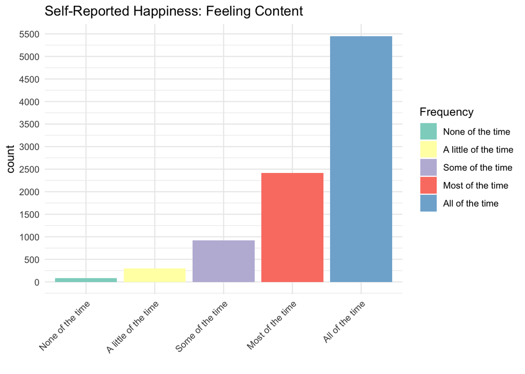

```r
#distribution of self-reported happiness
ggplot(savvydata, aes(savvydata$feeling_content, fill = savvydata$feeling_content))+
  geom_bar()+
  labs(title = "Self-Reported Happiness: Feeling Content", x = "", fill= "Frequency")+
  scale_x_discrete(guide = guide_axis(angle = 45 ))+
  scale_fill_brewer(palette = "Set3")+
  scale_y_continuous(breaks=c(0,500,1000,1500,2000,2500,3000,3500,
                              4000,4500,5000,5500))+
  theme_minimal()
```

```r
# misclassified observations
mean(as.character(training$feeling_content) != as.character(pred_train))
```

```
## [1] 0.4081283
```

```r
# accuracy / correctly classified
(CCR <- sum(diag(tab_train)) / sum(tab_train))
```

```
## [1] 0.5918717
```

For the training model of model 1 , there is 59% accuracy and 41% of misclassified observations.

```r
#Predicted Performance - Testing
pred_test <- predict(fitpolr_external, testing)
tab_test <- table(pred_test, testing$feeling_content)
print(tab_test)
```

```
##
## pred_test              None of the time A little of the time Some of the time
##   None of the time                    0                    0                0
##   A little of the time                0                    0                0
##   Some of the time                    0                    0                0
##   Most of the time                    5                    3               15
##   All of the time                    20                   87              261
##
## pred_test              Most of the time All of the time
##   None of the time                    0               0
##   A little of the time                0               0
##   Some of the time                    0               0
##   Most of the time                   20              27
##   All of the time                   705            1606
```

```r
table(pred_test, testing$feeling_content) %>%
  prop.table() %>% round(digits = 3)
```

```
##
## pred_test              None of the time A little of the time Some of the time
##   None of the time                0.000                0.000            0.000
##   A little of the time            0.000                0.000            0.000
##   Some of the time                0.000                0.000            0.000
##   Most of the time                0.002                0.001            0.005
##   All of the time                 0.007                0.032            0.095
##
## pred_test              Most of the time All of the time
##   None of the time                0.000           0.000
##   A little of the time            0.000           0.000
##   Some of the time                0.000           0.000
##   Most of the time                0.007           0.010
##   All of the time                 0.256           0.584
```

```r
#confusion matrix
confusionMatrix(pred_test, testing$feeling_content,
                positive = "pos")
```

```
## Confusion Matrix and Statistics
##
##                       Reference
## Prediction             None of the time A little of the time Some of the time
##   None of the time                    0                    0                0
##   A little of the time                0                    0                0
##   Some of the time                    0                    0                0
##   Most of the time                    5                    3               15
##   All of the time                    20                   87              261
##                       Reference
## Prediction             Most of the time All of the time
##   None of the time                    0               0
##   A little of the time                0               0
##   Some of the time                    0               0
##   Most of the time                   20              27
##   All of the time                   705            1606
##
## Overall Statistics
##
##                Accuracy : 0.5915
##                  95% CI : (0.5728, 0.6099)
##     No Information Rate : 0.594
##     P-Value [Acc > NIR] : 0.615
##
##                   Kappa : 0.0142
##
##  Mcnemar's Test P-Value : NA
##
## Statistics by Class:
##
##                      Class: None of the time Class: A little of the time
## Sensitivity                         0.000000                     0.00000
## Specificity                         1.000000                     1.00000
## Pos Pred Value                           NaN                         NaN
## Neg Pred Value                      0.990906                     0.96726
## Prevalence                          0.009094                     0.03274
## Detection Rate                      0.000000                     0.00000
## Detection Prevalence                0.000000                     0.00000
## Balanced Accuracy                   0.500000                     0.50000
##                      Class: Some of the time Class: Most of the time
## Sensitivity                           0.0000                0.027586
## Specificity                           1.0000                0.975296
## Pos Pred Value                           NaN                0.285714
## Neg Pred Value                        0.8996                0.736842
## Prevalence                            0.1004                0.263732
## Detection Rate                        0.0000                0.007275
## Detection Prevalence                  0.0000                0.025464
## Balanced Accuracy                     0.5000                0.501441
##                      Class: All of the time
## Sensitivity                         0.98347
## Specificity                         0.03853
## Pos Pred Value                      0.59948
## Neg Pred Value                      0.61429
## Prevalence                          0.59403
## Detection Rate                      0.58421
## Detection Prevalence                0.97454
## Balanced Accuracy                   0.51100
```

```r
#misclassified observations
mean(as.character(testing$feeling_content) != as.character(pred_test))
```

```
## [1] 0.4085122
```

```r
#accuracy / correctly classified
(CCR <- sum(diag(tab_test)) / sum(tab_test))
```

```
## [1] 0.5914878
```

For the testing model of Model 1, there is 59% accuracy and 41% of misclassified observations.

#### Model 2 - Big5

The second model will be Big Five Personality trait variables only to measure how well it predicts the psychological well-being or happiness.

```r
# Model 2 - Big5
fit_Big5 <- vglm(feeling_content ~ Neuroticism + Extraversion + Conscientiousness + Agreeableness + OpennessToExperience, cumulative(parallel=TRUE),data=training)
summary(fit_Big5)
```

```
##
## Call:
## vglm(formula = feeling_content ~ Neuroticism + Extraversion +
##     Conscientiousness + Agreeableness + OpennessToExperience,
##     family = cumulative(parallel = TRUE), data = training)
##
## Coefficients:
##                      Estimate Std. Error z value Pr(>|z|)
## (Intercept):1        -4.22511    0.13826 -30.559  < 2e-16 ***
## (Intercept):2        -2.59420    0.07575 -34.246  < 2e-16 ***
## (Intercept):3        -1.11376    0.05643 -19.737  < 2e-16 ***
## (Intercept):4         0.55513    0.05394  10.291  < 2e-16 ***
## Neuroticism           0.76709    0.03100  24.743  < 2e-16 ***
## Extraversion         -0.43065    0.02780 -15.489  < 2e-16 ***
## Conscientiousness    -0.21447    0.03192  -6.718 1.84e-11 ***
## Agreeableness         0.21329    0.03597   5.930 3.04e-09 ***
## OpennessToExperience -0.24104    0.03857  -6.249 4.13e-10 ***
## ---
## Signif. codes:  0 '***' 0.001 '**' 0.01 '*' 0.05 '.' 0.1 ' ' 1
##
## Names of linear predictors: logitlink(P[Y<=1]), logitlink(P[Y<=2]),
## logitlink(P[Y<=3]), logitlink(P[Y<=4])
##
## Residual deviance: 12064.93 on 25679 degrees of freedom
##
## Log-likelihood: -6032.465 on 25679 degrees of freedom
##
## Number of Fisher scoring iterations: 5
##
## Warning: Hauck-Donner effect detected in the following estimate(s):
## '(Intercept):1'
##
##
## Exponentiated coefficients:
##          Neuroticism         Extraversion    Conscientiousness
##            2.1534937            0.6500869            0.8069656
##        Agreeableness OpennessToExperience
##            1.2377452            0.7858066
```

```r
stepwise <- step4(fit_Big5)
```

```
## Start:  AIC=12082.93
## feeling_content ~ Neuroticism + Extraversion + Conscientiousness +
##     Agreeableness + OpennessToExperience
##
##                        Df Deviance   AIC
## <none>                       12065 12083
## - Agreeableness         1    12100 12116
## - OpennessToExperience  1    12104 12120
## - Conscientiousness     1    12110 12126
## - Extraversion          1    12308 12324
## - Neuroticism           1    12705 12721
```

```r
summary(stepwise)
```

```
##
## Call:
## vglm(formula = feeling_content ~ Neuroticism + Extraversion +
##     Conscientiousness + Agreeableness + OpennessToExperience,
##     family = cumulative(parallel = TRUE), data = training)
##
## Coefficients:
##                      Estimate Std. Error z value Pr(>|z|)
## (Intercept):1        -4.22511    0.13826 -30.559  < 2e-16 ***
## (Intercept):2        -2.59420    0.07575 -34.246  < 2e-16 ***
## (Intercept):3        -1.11376    0.05643 -19.737  < 2e-16 ***
## (Intercept):4         0.55513    0.05394  10.291  < 2e-16 ***
## Neuroticism           0.76709    0.03100  24.743  < 2e-16 ***
## Extraversion         -0.43065    0.02780 -15.489  < 2e-16 ***
## Conscientiousness    -0.21447    0.03192  -6.718 1.84e-11 ***
## Agreeableness         0.21329    0.03597   5.930 3.04e-09 ***
## OpennessToExperience -0.24104    0.03857  -6.249 4.13e-10 ***
## ---
## Signif. codes:  0 '***' 0.001 '**' 0.01 '*' 0.05 '.' 0.1 ' ' 1
##
## Names of linear predictors: logitlink(P[Y<=1]), logitlink(P[Y<=2]),
## logitlink(P[Y<=3]), logitlink(P[Y<=4])
##
## Residual deviance: 12064.93 on 25679 degrees of freedom
##
## Log-likelihood: -6032.465 on 25679 degrees of freedom
##
## Number of Fisher scoring iterations: 5
##
## Warning: Hauck-Donner effect detected in the following estimate(s):
## '(Intercept):1'
##
##
## Exponentiated coefficients:
##          Neuroticism         Extraversion    Conscientiousness
##            2.1534937            0.6500869            0.8069656
##        Agreeableness OpennessToExperience
##            1.2377452            0.7858066
```

vglm(formula = feeling_content ~ Neuroticism + Extraversion + Conscientiousness + Agreeableness + OpennessToExperience, family = cumulative(parallel = TRUE), data = training)

After stepwise regression, no variables were removed.

Next the ordinal logistic regression will be fit to build the proportional odds logistic regression to predict the class of multi-class ordered variables.

```r
#polr Big 5
fitpolr_Big5 <- polr(feeling_content ~ Neuroticism + Extraversion +
    Conscientiousness + Agreeableness + OpennessToExperience, data = training, Hess = TRUE)
summary(fitpolr_Big5)
```

```
## Call:
## polr(formula = feeling_content ~ Neuroticism + Extraversion +
##     Conscientiousness + Agreeableness + OpennessToExperience,
##     data = training, Hess = TRUE)
##
## Coefficients:
##                        Value Std. Error t value
## Neuroticism          -0.7671    0.03131 -24.500
## Extraversion          0.4307    0.02791  15.431
## Conscientiousness     0.2145    0.03204   6.694
## Agreeableness        -0.2133    0.03607  -5.913
## OpennessToExperience  0.2410    0.03891   6.194
##
## Intercepts:
##                                       Value    Std. Error t value
## None of the time|A little of the time  -4.2251   0.1382   -30.5778
## A little of the time|Some of the time  -2.5942   0.0762   -34.0558
## Some of the time|Most of the time      -1.1137   0.0571   -19.4901
## Most of the time|All of the time        0.5551   0.0546    10.1649
##
## Residual Deviance: 12064.93
## AIC: 12082.93
```

```r
# p-Value Calculation
(ctable <- coef(summary(fitpolr_Big5)))
```

```
##                                            Value Std. Error    t value
## Neuroticism                           -0.7670958 0.03130961 -24.500328
## Extraversion                           0.4306503 0.02790789  15.431130
## Conscientiousness                      0.2144749 0.03204155   6.693650
## Agreeableness                         -0.2132876 0.03607183  -5.912856
## OpennessToExperience                   0.2410034 0.03891125   6.193668
## None of the time|A little of the time -4.2250751 0.13817449 -30.577824
## A little of the time|Some of the time -2.5941523 0.07617360 -34.055791
## Some of the time|Most of the time     -1.1137172 0.05714264 -19.490124
## Most of the time|All of the time       0.5551086 0.05461007  10.164949
```

```r
p <- pnorm(abs(ctable[, "t value"]), lower.tail = FALSE) * 2
(ctable <- cbind(ctable, "p value" = p))
```

```
##                                            Value Std. Error    t value
## Neuroticism                           -0.7670958 0.03130961 -24.500328
## Extraversion                           0.4306503 0.02790789  15.431130
## Conscientiousness                      0.2144749 0.03204155   6.693650
## Agreeableness                         -0.2132876 0.03607183  -5.912856
## OpennessToExperience                   0.2410034 0.03891125   6.193668
## None of the time|A little of the time -4.2250751 0.13817449 -30.577824
## A little of the time|Some of the time -2.5941523 0.07617360 -34.055791
## Some of the time|Most of the time     -1.1137172 0.05714264 -19.490124
## Most of the time|All of the time       0.5551086 0.05461007  10.164949
##                                             p value
## Neuroticism                           1.465290e-132
## Extraversion                           1.010850e-53
## Conscientiousness                      2.176713e-11
## Agreeableness                          3.362256e-09
## OpennessToExperience                   5.878006e-10
## None of the time|A little of the time 2.413679e-205
## A little of the time|Some of the time 3.331820e-254
## Some of the time|Most of the time      1.331572e-84
## Most of the time|All of the time       2.842709e-24
```

```r
# convert the coefficients into odds ratios.
ci <- confint.default(fitpolr_Big5)
exp(cbind(OR = coef(fitpolr_Big5), ci))
```

```
##                             OR     2.5 %    97.5 %
## Neuroticism          0.4643597 0.4367207 0.4937480
## Extraversion         1.5382576 1.4563770 1.6247416
## Conscientiousness    1.2392110 1.1637815 1.3195294
## Agreeableness        0.8079238 0.7527764 0.8671112
## OpennessToExperience 1.2725253 1.1790850 1.3733706
```

Check predicted performance for Model 2

```r
# Predicted Performance for training model
pred_train_Big5 <- predict(fitpolr_Big5, training)
tab_train <- table(pred_train_Big5, training$feeling_content)
print(tab_train)
```

```
##
## pred_train_Big5        None of the time A little of the time Some of the time
##   None of the time                    0                    0                0
##   A little of the time                0                    2                2
##   Some of the time                   10                   28               26
##   Most of the time                   33                  105              243
##   All of the time                    16                   76              375
##
## pred_train_Big5        Most of the time All of the time
##   None of the time                    0               0
##   A little of the time                2               0
##   Some of the time                   36              11
##   Most of the time                  374             337
##   All of the time                  1282            3464
```

```r
table(pred_train_Big5, training$feeling_content) %>%
  prop.table() %>% round(digits = 3)
```

```
##
## pred_train_Big5        None of the time A little of the time Some of the time
##   None of the time                0.000                0.000            0.000
##   A little of the time            0.000                0.000            0.000
##   Some of the time                0.002                0.004            0.004
##   Most of the time                0.005                0.016            0.038
##   All of the time                 0.002                0.012            0.058
##
## pred_train_Big5        Most of the time All of the time
##   None of the time                0.000           0.000
##   A little of the time            0.000           0.000
##   Some of the time                0.006           0.002
##   Most of the time                0.058           0.052
##   All of the time                 0.200           0.539
```